# An EDA of the #SilentSam Dataset

|  | id_str | from_user | text | created_at | time | geo_coordinates | user_lang | in_reply_to_user_id_str | in_reply_to_screen_name | from_user_id_str | in_reply_to_status_id_str | source | profile_image_url | user_followers_count | user_friends_count | user_location |
| --- | --- | --- | --- | --- | --- | --- | --- | --- | --- | --- | --- | --- | --- | --- | --- | --- |
| 0 | 1099691632423854087 | miriammarkfield | RT @jordangreentcb: I filed my stories about t... | Sun Feb 24 15:24:51 +0000 2019 | 2019-02-24 15:24:51 | NaN | en | NaN | NaN | 102272618 | NaN | <a href="http://twitter.com" rel="nofollow">Tw... | http://pbs.twimg.com/profile_images/613115054/... | 38.0 | 294.0 | North Carolina |
| 1 | 1099563032219394049 | 1st_Reduce_Harm | RT @jordangreentcb: #silentsam https://t.co/55... | Sun Feb 24 06:53:50 +0000 2019 | 2019-02-24 06:53:50 | NaN | en | NaN | NaN | 964521738938830848 | NaN | <a href="http://twitter.com/download/android" ... | http://abs.twimg.com/sticky/default_profile_im... | 12.0 | 98.0 | Not "the Midwest", THE NORTH. |
| 2 | 1099726269858631680 | SilentSamIAm | RT @jordangreentcb: Antiracists tell neo-Confe... | Sun Feb 24 17:42:29 +0000 2019 | 2019-02-24 17:42:29 | NaN | en | NaN | NaN | 913775281881612288 | NaN | <a href="http://twitter.com/download/iphone" r... | http://pbs.twimg.com/profile_images/1100091256... | 373.0 | 146.0 | NaN |
| 3 | 1099629537028071424 | IGD_News | RT @adaure: Drowned out by the chants of “go h... | Sun Feb 24 11:18:06 +0000 2019 | 2019-02-24 11:18:06 | NaN | en | NaN | NaN | 3289440085 | NaN | <a href="http://twitter.com/download/android" ... | http://pbs.twimg.com/profile_images/9867907451... | 45665.0 | 1626.0 | So-Called North America |
| 4 | 1099633891390951425 | tartnyc | RT @jordangreentcb: Antiracists tell neo-Confe... | Sun Feb 24 11:35:24 +0000 2019 | 2019-02-24 11:35:24 | NaN | en | NaN | NaN | 159617463 | NaN | <a href="https://mobile.twitter.com" rel="nofo... | http://pbs.twimg.com/profile_images/7060132255... | 2272.0 | 4343.0 | NaN |
| 5 | 1100960843397771264 | DT_Sensual | People that seek separation without tolerance ... | Thu Feb 28 03:28:14 +0000 2019 | 2019-02-28 03:28:14 | NaN | en | NaN | NaN | 3767590641 | NaN | <a href="http://twitter.com/download/android" ... | http://pbs.twimg.com/profile_images/6472784839... | 8.0 | NaN | Cary, NC |
| 6 | 1099964758130749441 | bluemazatl | RT @jordangreentcb: The coalition of neo-Confe... | Mon Feb 25 09:30:09 +0000 2019 | 2019-02-25 09:30:09 | NaN | en | NaN | NaN | 236518615 | NaN | <a href="http://twitter.com/download/android" ... | http://pbs.twimg.com/profile_images/1099837796... | 2947.0 | 4640.0 | Valsetz, Oregon |
| 7 | 1099699486996221952 | KendraElWa | RT @jordangreentcb: The coalition of neo-Confe... | Sun Feb 24 15:56:03 +0000 2019 | 2019-02-24 15:56:03 | NaN | en | NaN | NaN | 1548189294 | NaN | <a href="http://twitter.com/download/iphone" r... | http://pbs.twimg.com/profile_images/1079606500... | 1732.0 | 1516.0 | Pontiac, MI Charlotte, NC |
| 8 | 1100041172968529920 | brklwyr | In awe of the great print/online work this yea... | Mon Feb 25 14:33:48 +0000 2019 | 2019-02-25 14:33:48 | NaN | en | NaN | NaN | 3304751077 | NaN | <a href="http://twitter.com/download/iphone" r... | http://pbs.twimg.com/profile_images/6280245257... | 85.0 | 46.0 | NaN |
| 9 | 1099629921175924736 | cujowasagoodboy | RT @adaure: Drowned out by the chants of “go h... | Sun Feb 24 11:19:38 +0000 2019 | 2019-02-24 11:19:38 | NaN | en | NaN | NaN | 60799419 | NaN | <a href="http://twitter.com/download/android" ... | http://pbs.twimg.com/profile_images/1058093672... | 2306.0 | 2159.0 | Tucson, AZ |
| 10 | 1099635971669323778 | M_Abdirizak93 | RT @jordangreentcb: #silentsam https://t.co/55... | Sun Feb 24 11:43:40 +0000 2019 | 2019-02-24 11:43:40 | NaN | en | NaN | NaN | 2419161339 | NaN | <a href="http://twitter.com" rel="nofollow">Tw... | http://pbs.twimg.com/profile_images/9674572918... | 195.0 | 1327.0 | Nairobi, Kenya |
| 11 | 1099712013348028422 | talkingattheTV2 | RT @jordangreentcb: The coalition of neo-Confe... | Sun Feb 24 16:45:50 +0000 2019 | 2019-02-24 16:45:50 | NaN | en | NaN | NaN | 2535755094 | NaN | <a href="http://twitter.com/download/iphone" r... | http://pbs.twimg.com/profile_images/1079159005... | 392.0 | 1238.0 | BusyTown, NC |
| 12 | 1099823473260675072 | margaretcmaurer | RT @jordangreentcb: I filed my stories about t... | Mon Feb 25 00:08:44 +0000 2019 | 2019-02-25 00:08:44 | NaN | en | NaN | NaN | 997159895458861056 | NaN | <a href="http://twitter.com/download/iphone" r... | http://pbs.twimg.com/profile_images/9971632963... | 206.0 | 331.0 | Chapel Hill, NC |
| 13 | 1099696134304468994 | takeactionch | RT @AylingLindsay: Before the rally, antiracis... | Sun Feb 24 15:42:44 +0000 2019 | 2019-02-24 15:42:44 | NaN | en | NaN | NaN | 1036644577321660416 | NaN | <a href="http://twitter.com/download/iphone" r... | http://pbs.twimg.com/profile_images/1092956287... | 1419.0 | 852.0 | Chapel Hill, NC |
| 14 | 1099688339622506499 | dhosterman | RT @jordangreentcb: The coalition of neo-Confe... | Sun Feb 24 15:11:46 +0000 2019 | 2019-02-24 15:11:46 | NaN | en | NaN | NaN | 16826762 | NaN | <a href="http://twitter.com/download/android" ... | http://pbs.twimg.com/profile_images/3788000001... | 539.0 | 73.0 | Durham, NC |
| 15 | 1099674637695414272 | LocoCravey | RT @jordangreentcb: The coalition of neo-Confe... | Sun Feb 24 14:17:19 +0000 2019 | 2019-02-24 14:17:19 | NaN | en | NaN | NaN | 1119391856 | NaN | <a href="http://twitter.com/download/android" ... | http://pbs.twimg.com/profile_images/8399781338... | 1675.0 | 2055.0 | Carrboro, North Carolina |
| 16 | 1099654795248484352 | 226press | RT @jordangreentcb: Antiracists tell neo-Confe... | Sun Feb 24 12:58:28 +0000 2019 | 2019-02-24 12:58:28 | NaN | en | NaN | NaN | 1710163176 | NaN | <a href="http://twitter.com/download/iphone" r... | http://pbs.twimg.com/profile_images/3788000003... | 160.0 | 552.0 | Philadelphia, PA |
| 17 | 1099748421790040070 | constantnatalie | RT @jordangreentcb: The coalition of neo-Confe... | Sun Feb 24 19:10:30 +0000 2019 | 2019-02-24 19:10:30 | NaN | en | NaN | NaN | 279660360 | NaN | <a href="http://twitter.com/download/android" ... | http://pbs.twimg.com/profile_images/2844976143... | 8499.0 | 9227.0 | chicago |
| 18 | 1099924440010366976 | tmorman | RT @jordangreentcb: I filed my stories about t... | Mon Feb 25 06:49:56 +0000 2019 | 2019-02-25 06:49:56 | NaN | en | NaN | NaN | 52315263 | NaN | <a href="https://mobile.twitter.com" rel="nofo... | http://pbs.twimg.com/profile_images/297596442/... | 499.0 | 389.0 | Raleigh, NC, Earth |
| 19 | 1099634113034838017 | amymorto | RT @jordangreentcb: Antiracists tell neo-Confe... | Sun Feb 24 11:36:17 +0000 2019 | 2019-02-24 11:36:17 | NaN | en | NaN | NaN | 172773121 | NaN | <a href="http://twitter.com/download/android" ... | http://pbs.twimg.com/profile_images/1075060605... | 56.0 | 121.0 | NaN |
| 20 | 1100498288116203520 | acthistreview | .@sams_reckoning is an amazing activist-histor... | Tue Feb 26 20:50:12 +0000 2019 | 2019-02-26 20:50:12 | NaN | en | NaN | NaN | 804416609074876416 | NaN | <a href="http://twitter.com" rel="nofollow">Tw... | http://pbs.twimg.com/profile_images/9203423343... | 1474.0 | 2626.0 | NaN |
| 21 | 1099632217683382274 | Dj_Sepultourist | RT @jordangreentcb: Antiracists tell neo-Confe... | Sun Feb 24 11:28:45 +0000 2019 | 2019-02-24 11:28:45 | NaN | en | NaN | NaN | 1734497964 | NaN | <a href="http://twitter.com/download/iphone" r... | http://pbs.twimg.com/profile_images/1099064274... | 473.0 | 419.0 | Poop, yucatan |
| 22 | 1099908273568923648 | tarheelesq | RT @jordangreentcb: The coalition of neo-Confe... | Mon Feb 25 05:45:42 +0000 2019 | 2019-02-25 05:45:42 | NaN | en | NaN | NaN | 264506309 | NaN | <a href="http://twitter.com/#!/download/ipad" ... | http://pbs.twimg.com/profile_images/1444053634... | 99.0 | 148.0 | NaN |
| 23 | 1099676718707720193 | angry_barbaloot | RT @jordangreentcb: I filed my stories about t... | Sun Feb 24 14:25:35 +0000 2019 | 2019-02-24 14:25:35 | NaN | en | NaN | NaN | 820491202931855360 | NaN | <a href="http://twitter.com" rel="nofollow">Tw... | http://pbs.twimg.com/profile_images/8217790570... | 207.0 | 958.0 | Off |
| 24 | 1099633208856100864 | condorscondor | RT @jordangreentcb: Antiracists tell neo-Confe... | Sun Feb 24 11:32:41 +0000 2019 | 2019-02-24 11:32:41 | NaN | en | NaN | NaN | 1416424189 | NaN | <a href="http://twitter.com/download/android" ... | http://pbs.twimg.com/profile_images/6155761326... | 574.0 | 1049.0 | Hell on Earth |
| 25 | 1099683511211040772 | chogmorson | RT @jordangreentcb: The coalition of neo-Confe... | Sun Feb 24 14:52:34 +0000 2019 | 2019-02-24 14:52:34 | NaN | en | NaN | NaN | 2214181885 | NaN | <a href="http://twitter.com" rel="nofollow">Tw... | http://pbs.twimg.com/profile_images/3788000007... | 314.0 | 1243.0 | North Carolina, USA |
| 26 | 1099634934938062854 | AndreFastayrol | RT @adaure: Drowned out by the chants of “go h... | Sun Feb 24 11:39:33 +0000 2019 | 2019-02-24 11:39:33 | NaN | fr | NaN | NaN | 362463937 | NaN | <a href="http://twitter.com/#!/download/ipad" ... | http://pbs.twimg.com/profile_images/9080582319... | 306.0 | 836.0 | Lemograd (Petite Russie) |
| 27 | 1099654123295854593 | takethemdownnow | RT @jordangreentcb: “May Turner, John Brown, a... | Sun Feb 24 12:55:48 +0000 2019 | 2019-02-24 12:55:48 | NaN | en | NaN | NaN | 903268859922276352 | NaN | <a href="http://twitter.com/download/iphone" r... | http://pbs.twimg.com/profile_images/9032709830... | 240.0 | 104.0 | NaN |
| 28 | 1099692140722933762 | magus721rn | RT @jordangreentcb: Antiracists tell neo-Confe... | Sun Feb 24 15:26:52 +0000 2019 | 2019-02-24 15:26:52 | NaN | en | NaN | NaN | 70606360 | NaN | <a href="http://twitter.com/download/android" ... | http://pbs.twimg.com/profile_images/1090635886... | 854.0 | 4291.0 | WAKANDA! |
| 29 | 1099675465491599360 | RichmondDoc | RT @jordangreentcb: The coalition of neo-Confe... | Sun Feb 24 14:20:36 +0000 2019 | 2019-02-24 14:20:36 | NaN | en | NaN | NaN | 20865979 | NaN | <a href="http://twitter.com/download/iphone" r... | http://pbs.twimg.com/profile_images/8047413601... | 8261.0 | 3416.0 | NaN |
| ... | ... | ... | ... | ... | ... | ... | ... | ... | ... | ... | ... | ... | ... | ... | ... | ... |
| 59224 | 786347824875122688 | knightstivender | Here at the @franklinhomepg candidate forum. O... | Wed Oct 12 23:28:25 +0000 2016 | 2016-10-13 00:28:25 | NaN | en | NaN | NaN | 15444208 | NaN | <a href="http://twitter.com/download/iphone" r... | http://pbs.twimg.com/profile_images/6156011813... | 4827.0 | 3892.0 | Nashville, Tennessee |
| 59225 | 780952354141024256 | Big_G_09 | @BradyTrett #SilentSam 👍 | Wed Sep 28 02:08:45 +0000 2016 | 2016-09-28 03:08:45 | NaN | en | 381259616.0 | BradyTrett | 1060182799 | 7.805842e+17 | <a href="http://www.twitter.com" rel="nofollow... | http://pbs.twimg.com/profile_images/1079916441... | 11299.0 | 12145.0 | Saskatoon, Saskatchewan 🇨🇦 @rinks @rings @gym... |
| 59226 | 707340331252060160 | CampusY_UNC | RT @iah_unc: #artsandsocialjustice grant deadl... | Tue Mar 08 23:00:51 +0000 2016 | 2016-03-08 23:00:51 | NaN | en | NaN | NaN | 542574605 | NaN | <a href="http://www.hootsuite.com" rel="nofoll... | http://pbs.twimg.com/profile_images/7710370575... | 2587.0 | 412.0 | UNC-Chapel Hill |
| 59227 | 703321437600391168 | CPJ_UNC | What to do with #SilentSam at @UNC? Libbie Wei... | Fri Feb 26 20:51:12 +0000 2016 | 2016-02-26 20:51:12 | NaN | en | NaN | NaN | 3092622909 | NaN | <a href="http://twitter.com" rel="nofollow">Tw... | http://pbs.twimg.com/profile_images/6420412326... | 154.0 | 313.0 | Chapel Hill, North Carolina |
| 59228 | 741084605680386048 | laurenps_ | "Y'alls stories from high school make me glad ... | Fri Jun 10 01:48:33 +0000 2016 | 2016-06-10 02:48:33 | NaN | en | NaN | NaN | 335122952 | NaN | <a href="http://twitter.com/download/iphone" r... | http://pbs.twimg.com/profile_images/1096934237... | 1652.0 | 883.0 | Seymour, TN |
| 59229 | 719993098290376704 | Robert_Smalls62 | New Research Guide on the #SilentSam Confedera... | Tue Apr 12 20:58:26 +0000 2016 | 2016-04-12 21:58:26 | NaN | en | NaN | NaN | 716149776165670912 | NaN | <a href="http://twitter.com" rel="nofollow">Tw... | http://pbs.twimg.com/profile_images/7161523852... | 87.0 | 123.0 | NaN |
| 59230 | 695069171751743488 | WilsonforSBP | A: Jim Carr #SilentSam dedication an example o... | Thu Feb 04 02:19:38 +0000 2016 | 2016-02-04 02:19:38 | NaN | en | NaN | NaN | 4711040003 | NaN | <a href="http://twitter.com" rel="nofollow">Tw... | http://pbs.twimg.com/profile_images/6917414376... | 22.0 | 48.0 | NaN |
| 59231 | 748218429761413120 | _thepopshop | Canada Day Strawberries with shots of #Silent... | Wed Jun 29 18:15:49 +0000 2016 | 2016-06-29 19:15:49 | NaN | en | NaN | NaN | 1129817234 | NaN | <a href="http://www.facebook.com/twitter" rel=... | http://pbs.twimg.com/profile_images/4550428300... | 172.0 | 154.0 | Durham Region & the GTA |
| 59232 | 695076475649802241 | WilsonforSBP | "If we want to move Silent Sam, we have to mov... | Thu Feb 04 02:48:40 +0000 2016 | 2016-02-04 02:48:40 | NaN | en | NaN | NaN | 4711040003 | NaN | <a href="http://twitter.com" rel="nofollow">Tw... | http://pbs.twimg.com/profile_images/6917414376... | 22.0 | 48.0 | NaN |
| 59233 | 806129837110792193 | Big_G_09 | @sec1968 Just got outta Edmonton and Arizona! ... | Tue Dec 06 13:35:04 +0000 2016 | 2016-12-06 13:35:04 | NaN | en | 486007290.0 | sec1968 | 1060182799 | 8.061295e+17 | <a href="http://twitter.com" rel="nofollow">Tw... | http://pbs.twimg.com/profile_images/1079916441... | 11299.0 | 12145.0 | Saskatoon, Saskatchewan 🇨🇦 @rinks @rings @gym... |
| 59234 | 787714497855180800 | calgaryhester | @sambradd P.S. I like that there's a range of ... | Sun Oct 16 17:59:05 +0000 2016 | 2016-10-16 18:59:05 | NaN | en | 21975684.0 | drawing_change | 756116796 | 7.877103e+17 | <a href="http://twitter.com" rel="nofollow">Tw... | http://pbs.twimg.com/profile_images/1042137699... | 1589.0 | 262.0 | Calgary, Alberta, Canada |
| 59235 | 704388417069703173 | cdwyer0213 | "Silent Sam may be without ammunition, but he ... | Mon Feb 29 19:31:00 +0000 2016 | 2016-02-29 19:31:00 | NaN | en | NaN | NaN | 26049846 | NaN | <a href="http://twitter.com/download/iphone" r... | http://pbs.twimg.com/profile_images/1081533839... | 259.0 | 985.0 | Durham, NC |
| 59236 | 786250445287284737 | tndp | Tennesseans need to know where candidates stan... | Wed Oct 12 17:01:28 +0000 2016 | 2016-10-12 18:01:28 | NaN | en | NaN | NaN | 19916171 | NaN | <a href="https://about.twitter.com/products/tw... | http://pbs.twimg.com/profile_images/8981954332... | 17077.0 | 2818.0 | Tennessee |
| 59237 | 799762392825679874 | Avilyst | Silent sam Please be good to me tonight 😜😂 #Si... | Fri Nov 18 23:53:07 +0000 2016 | 2016-11-18 23:53:07 | NaN | en | NaN | NaN | 3301058843 | NaN | <a href="http://twitter.com/download/iphone" r... | http://pbs.twimg.com/profile_images/1084878393... | 665.0 | 326.0 | Ontario, Canada |
| 59238 | 718570586113486848 | saveusalll | #beer #wine #heineken #greekwine #liquor #sile... | Fri Apr 08 22:45:52 +0000 2016 | 2016-04-08 23:45:52 | NaN | en | NaN | NaN | 2161315426 | NaN | <a href="http://instagram.com" rel="nofollow">... | http://pbs.twimg.com/profile_images/1049095343... | 3802.0 | 4944.0 | Mississauga Ontario Canada 🍁 |
| 59239 | 713028722786340869 | UNChistory | RT @iah_unc: Faculty Fellow @UNChistory Fitzhu... | Thu Mar 24 15:44:29 +0000 2016 | 2016-03-24 15:44:29 | NaN | en | NaN | NaN | 249313687 | NaN | <a href="http://twitter.com" rel="nofollow">Tw... | http://pbs.twimg.com/profile_images/9257156162... | 1468.0 | 632.0 | Chapel Hill, NC |
| 59240 | 804893314864578560 | Schmocki_Boi | @SI_ChrisBallard @samhinkie great article. If... | Sat Dec 03 03:41:35 +0000 2016 | 2016-12-03 03:41:35 | NaN | en | 84499860.0 | SI_ChrisBallard | 345768912 | 8.040047e+17 | <a href="http://twitter.com/download/android" ... | http://pbs.twimg.com/profile_images/1080537880... | 218.0 | 793.0 | Philadelphia, PA |
| 59241 | 696090738598109185 | Surreyissafe | @CBCNews she looks like a plastic blow up doll... | Sat Feb 06 21:58:59 +0000 2016 | 2016-02-06 21:58:59 | NaN | en | 6433472.0 | CBCNews | 2393043239 | 6.960835e+17 | <a href="http://twitter.com/download/iphone" r... | http://pbs.twimg.com/profile_images/7030861141... | 206.0 | 785.0 | newton wave pool |
| 59242 | 807552112020295682 | ljhhrpr | Silent Sam!in the am fuck yeah!\n#silentsam. A... | Sat Dec 10 11:46:41 +0000 2016 | 2016-12-10 11:46:41 | NaN | en | NaN | NaN | 804892396467212288 | NaN | <a href="http://twitter.com/download/android" ... | http://pbs.twimg.com/profile_images/1056427608... | 34.0 | 103.0 | NaN |
| 59243 | 706583343199100929 | TarHeelAltRight | @jdmar3 @ChapelHillNews1 Ah yes, employing an ... | Sun Mar 06 20:52:51 +0000 2016 | 2016-03-06 20:52:51 | NaN | en | 19765236.0 | jdmar3 | 706016001708703744 | 7.065479e+17 | <a href="http://twitter.com" rel="nofollow">Tw... | http://pbs.twimg.com/profile_images/7060171644... | 30.0 | 57.0 | NaN |
| 59244 | 712774913065684993 | iah_unc | Faculty Fellow @UNChistory Fitzhugh Brundage d... | Wed Mar 23 22:55:56 +0000 2016 | 2016-03-23 22:55:56 | NaN | en | NaN | NaN | 358163177 | NaN | <a href="http://twitter.com" rel="nofollow">Tw... | http://pbs.twimg.com/profile_images/8920021583... | 1325.0 | 713.0 | Chapel Hill, NC |
| 59245 | 706535265121214464 | TriangleEditor | RT @jdmar3: A monument to unknown dead people ... | Sun Mar 06 17:41:48 +0000 2016 | 2016-03-06 17:41:48 | NaN | en | NaN | NaN | 55018922 | NaN | <a href="https://about.twitter.com/products/tw... | http://pbs.twimg.com/profile_images/8768128037... | 7068.0 | 817.0 | Chapel Hill, NC |
| 59246 | 707345550455214080 | AshHeffe | RT @iah_unc: #artsandsocialjustice grant deadl... | Tue Mar 08 23:21:35 +0000 2016 | 2016-03-08 23:21:35 | NaN | en | NaN | NaN | 2185473637 | NaN | <a href="http://twitter.com/download/iphone" r... | http://pbs.twimg.com/profile_images/7829517812... | 358.0 | 298.0 | NaN |
| 59247 | 706547628620816385 | TarHeelAltRight | @jdmar3 @ChapelHillNews1 Because #SilentSam is... | Sun Mar 06 18:30:56 +0000 2016 | 2016-03-06 18:30:56 | NaN | en | 19765236.0 | jdmar3 | 706016001708703744 | 7.065298e+17 | <a href="http://twitter.com" rel="nofollow">Tw... | http://pbs.twimg.com/profile_images/7060171644... | 30.0 | 57.0 | NaN |
| 59248 | 757052083728187396 | niiikkkiii_mn | I shall drown myself in this beautiful bottle ... | Sun Jul 24 03:17:36 +0000 2016 | 2016-07-24 04:17:36 | NaN | en | NaN | NaN | 4055910857 | NaN | <a href="http://twitter.com/download/iphone" r... | http://pbs.twimg.com/profile_images/6591110684... | 39.0 | 69.0 | NaN |
| 59249 | 695076381097594880 | WilsonforSBP | A: What will you do to support the students in... | Thu Feb 04 02:48:17 +0000 2016 | 2016-02-04 02:48:17 | NaN | en | NaN | NaN | 4711040003 | NaN | <a href="http://twitter.com" rel="nofollow">Tw... | http://pbs.twimg.com/profile_images/6917414376... | 22.0 | 48.0 | NaN |
| 59250 | 717876586234642432 | viejas46 | @RealGlenMacnow That would be like #SilentSam. | Thu Apr 07 00:48:10 +0000 2016 | 2016-04-07 01:48:10 | NaN | en | 963038778.0 | RealGlenMacnow | 39248138 | 7.178748e+17 | <a href="http://twitter.com" rel="nofollow">Tw... | http://pbs.twimg.com/profile_images/1931035440... | 404.0 | 870.0 | VA Beach |
| 59251 | 725473895881531392 | LokoVybe | Bout to have #shot of some #SilentSam and munc... | Wed Apr 27 23:57:10 +0000 2016 | 2016-04-28 00:57:10 | NaN | en | NaN | NaN | 524000395 | NaN | <a href="http://www.twitter.com" rel="nofollow... | http://pbs.twimg.com/profile_images/4492328506... | 8.0 | 11.0 | Sauga City/T-Dot |
| 59252 | 708729711300489216 | haley_nm | I apologize to anyone that I was talking to la... | Sat Mar 12 19:01:45 +0000 2016 | 2016-03-12 19:01:45 | NaN | en | NaN | NaN | 327822558 | NaN | <a href="http://twitter.com/download/iphone" r... | http://pbs.twimg.com/profile_images/8313639137... | 915.0 | 95.0 | NaN |
| 59253 | 706535192706420736 | LocoCravey | RT @jdmar3: A monument to unknown dead people ... | Sun Mar 06 17:41:31 +0000 2016 | 2016-03-06 17:41:31 | NaN | en | NaN | NaN | 1119391856 | NaN | <a href="http://twitter.com" rel="nofollow">Tw... | http://pbs.twimg.com/profile_images/8399781338... | 1675.0 | 2055.0 | Carrboro, North Carolina |

We found some duplicates in the dataset! Let's get rid of them!

```python
db2.id_str.duplicated().value_counts()
```

```
False    59216
True        38
Name: id_str, dtype: int64
```

```python
db2_nodup=db2[db2.id_str.duplicated()==False]
```

Then, let's cast out the url attributes - not useful for now!

```python
db3=db2_nodup.drop(columns=["user_profile_image_url","user_profile_background_image_url","profile_image_url","status_url"])
```

Again, some attributes contains the same info, such as **created_at** and **time**. Let's keep only one of them in our dataset.

```python
db3=db3.drop(columns=['created_at','in_reply_to_user_id_str'])
```

```python
db3
```

|  | id_str | from_user | text | time | geo_coordinates | user_lang | in_reply_to_screen_name | from_user_id_str | in_reply_to_status_id_str | source | ... | user_created_at | user_geo_enabled | user_listed_count | user_verified | user_statuses_count | user_screen_name | user_favourites_count | possibly_sensitive | lang_trans | date |
| --- | --- | --- | --- | --- | --- | --- | --- | --- | --- | --- | --- | --- | --- | --- | --- | --- | --- | --- | --- | --- | --- |
| 0 | 1099691632423854087 | miriammarkfield | RT @jordangreentcb: I filed my stories about t... | 2019-02-24 15:24:51 | NaN | en | NaN | 102272618 | NaN | <a href="http://twitter.com" rel="nofollow">Tw... | ... | Wed Jan 06 04:36:47 +0000 2010 | NaN | NaN | NaN | 305 | miriammarkfield | 1161.0 | NaN | English | 2019-02-24 |
| 1 | 1099563032219394049 | 1st_Reduce_Harm | RT @jordangreentcb: #silentsam https://t.co/55... | 2019-02-24 06:53:50 | NaN | en | NaN | 964521738938830848 | NaN | <a href="http://twitter.com/download/android" ... | ... | Fri Feb 16 15:27:57 +0000 2018 | NaN | NaN | NaN | 818 | 1st_Reduce_Harm | 1947.0 | NaN | English | 2019-02-24 |
| 2 | 1099726269858631680 | SilentSamIAm | RT @jordangreentcb: Antiracists tell neo-Confe... | 2019-02-24 17:42:29 | NaN | en | NaN | 913775281881612288 | NaN | <a href="http://twitter.com/download/iphone" r... | ... | Fri Sep 29 14:39:39 +0000 2017 | NaN | 2.0 | NaN | 2665 | SilentSamIAm | 2585.0 | NaN | English | 2019-02-24 |
| 3 | 1099629537028071424 | IGD_News | RT @adaure: Drowned out by the chants of “go h... | 2019-02-24 11:18:06 | NaN | en | NaN | 3289440085 | NaN | <a href="http://twitter.com/download/android" ... | ... | Fri Jul 24 04:58:59 +0000 2015 | True | 691.0 | NaN | 35727 | IGD_News | 22187.0 | NaN | English | 2019-02-24 |
| 4 | 1099633891390951425 | tartnyc | RT @jordangreentcb: Antiracists tell neo-Confe... | 2019-02-24 11:35:24 | NaN | en | NaN | 159617463 | NaN | <a href="https://mobile.twitter.com" rel="nofo... | ... | Fri Jun 25 22:02:01 +0000 2010 | NaN | 174.0 | NaN | 35618 | tartnyc | 37056.0 | NaN | English | 2019-02-24 |
| 5 | 1100960843397771264 | DT_Sensual | People that seek separation without tolerance ... | 2019-02-28 03:28:14 | NaN | en | NaN | 3767590641 | NaN | <a href="http://twitter.com/download/android" ... | ... | Fri Sep 25 05:07:55 +0000 2015 | NaN | 6.0 | NaN | 150 | DT_Sensual | 6.0 | NaN | English | 2019-02-28 |
| 6 | 1099964758130749441 | bluemazatl | RT @jordangreentcb: The coalition of neo-Confe... | 2019-02-25 09:30:09 | NaN | en | NaN | 236518615 | NaN | <a href="http://twitter.com/download/android" ... | ... | Mon Jan 10 19:37:26 +0000 2011 | True | 55.0 | NaN | 33926 | bluemazatl | 66291.0 | NaN | English | 2019-02-25 |
| 7 | 1099699486996221952 | KendraElWa | RT @jordangreentcb: The coalition of neo-Confe... | 2019-02-24 15:56:03 | NaN | en | NaN | 1548189294 | NaN | <a href="http://twitter.com/download/iphone" r... | ... | Wed Jun 26 13:32:51 +0000 2013 | True | 12.0 | NaN | 1737 | KendraElWa | 12963.0 | NaN | English | 2019-02-24 |
| 8 | 1100041172968529920 | brklwyr | In awe of the great print/online work this yea... | 2019-02-25 14:33:48 | NaN | en | NaN | 3304751077 | NaN | <a href="http://twitter.com/download/iphone" r... | ... | Mon Aug 03 01:55:51 +0000 2015 | NaN | NaN | NaN | 82 | brklwyr | 31.0 | NaN | English | 2019-02-25 |
| 9 | 1099629921175924736 | cujowasagoodboy | RT @adaure: Drowned out by the chants of “go h... | 2019-02-24 11:19:38 | NaN | en | NaN | 60799419 | NaN | <a href="http://twitter.com/download/android" ... | ... | Tue Jul 28 03:35:27 +0000 2009 | NaN | 193.0 | NaN | 167938 | cujowasagoodboy | 366471.0 | NaN | English | 2019-02-24 |
| 10 | 1099635971669323778 | M_Abdirizak93 | RT @jordangreentcb: #silentsam https://t.co/55... | 2019-02-24 11:43:40 | NaN | en | NaN | 2419161339 | NaN | <a href="http://twitter.com" rel="nofollow">Tw... | ... | Tue Mar 18 04:32:51 +0000 2014 | NaN | NaN | NaN | 1249 | M_Abdirizak93 | 10248.0 | NaN | English | 2019-02-24 |
| 11 | 1099712013348028422 | talkingattheTV2 | RT @jordangreentcb: The coalition of neo-Confe... | 2019-02-24 16:45:50 | NaN | en | NaN | 2535755094 | NaN | <a href="http://twitter.com/download/iphone" r... | ... | Fri May 30 20:02:28 +0000 2014 | True | 7.0 | NaN | 12450 | talkingattheTV2 | 33780.0 | NaN | English | 2019-02-24 |
| 12 | 1099823473260675072 | margaretcmaurer | RT @jordangreentcb: I filed my stories about t... | 2019-02-25 00:08:44 | NaN | en | NaN | 997159895458861056 | NaN | <a href="http://twitter.com/download/iphone" r... | ... | Thu May 17 17:00:20 +0000 2018 | NaN | 1.0 | NaN | 564 | margaretcmaurer | 3144.0 | NaN | English | 2019-02-25 |
| 13 | 1099696134304468994 | takeactionch | RT @AylingLindsay: Before the rally, antiracis... | 2019-02-24 15:42:44 | NaN | en | NaN | 1036644577321660416 | NaN | <a href="http://twitter.com/download/iphone" r... | ... | Mon Sep 03 15:58:21 +0000 2018 | NaN | 15.0 | NaN | 2199 | takeactionch | 5843.0 | NaN | English | 2019-02-24 |
| 14 | 1099688339622506499 | dhosterman | RT @jordangreentcb: The coalition of neo-Confe... | 2019-02-24 15:11:46 | NaN | en | NaN | 16826762 | NaN | <a href="http://twitter.com/download/android" ... | ... | Fri Oct 17 16:27:17 +0000 2008 | NaN | 10.0 | NaN | 3827 | dhosterman | 3668.0 | NaN | English | 2019-02-24 |
| 15 | 1099674637695414272 | LocoCravey | RT @jordangreentcb: The coalition of neo-Confe... | 2019-02-24 14:17:19 | NaN | en | NaN | 1119391856 | NaN | <a href="http://twitter.com/download/android" ... | ... | Fri Jan 25 14:01:05 +0000 2013 | True | 104.0 | NaN | 55658 | LocoCravey | 76345.0 | NaN | English | 2019-02-24 |
| 16 | 1099654795248484352 | 226press | RT @jordangreentcb: Antiracists tell neo-Confe... | 2019-02-24 12:58:28 | NaN | en | NaN | 1710163176 | NaN | <a href="http://twitter.com/download/iphone" r... | ... | Thu Aug 29 14:38:34 +0000 2013 | NaN | 4.0 | NaN | 5334 | 226press | 8724.0 | NaN | English | 2019-02-24 |
| 17 | 1099748421790040070 | constantnatalie | RT @jordangreentcb: The coalition of neo-Confe... | 2019-02-24 19:10:30 | NaN | en | NaN | 279660360 | NaN | <a href="http://twitter.com/download/android" ... | ... | Sat Apr 09 18:51:54 +0000 2011 | NaN | 328.0 | NaN | 95389 | constantnatalie | 10596.0 | NaN | English | 2019-02-24 |
| 18 | 1099924440010366976 | tmorman | RT @jordangreentcb: I filed my stories about t... | 2019-02-25 06:49:56 | NaN | en | NaN | 52315263 | NaN | <a href="https://mobile.twitter.com" rel="nofo... | ... | Tue Jun 30 05:30:29 +0000 2009 | NaN | 29.0 | NaN | 15279 | tmorman | 2486.0 | NaN | English | 2019-02-25 |
| 19 | 1099634113034838017 | amymorto | RT @jordangreentcb: Antiracists tell neo-Confe... | 2019-02-24 11:36:17 | NaN | en | NaN | 172773121 | NaN | <a href="http://twitter.com/download/android" ... | ... | Fri Jul 30 15:34:39 +0000 2010 | NaN | NaN | NaN | 1480 | amymorto | 1764.0 | NaN | English | 2019-02-24 |
| 20 | 1100498288116203520 | acthistreview | .@sams_reckoning is an amazing activist-histor... | 2019-02-26 20:50:12 | NaN | en | NaN | 804416609074876416 | NaN | <a href="http://twitter.com" rel="nofollow">Tw... | ... | Thu Dec 01 20:07:19 +0000 2016 | NaN | 21.0 | NaN | 1239 | acthistreview | 1158.0 | NaN | English | 2019-02-26 |
| 21 | 1099632217683382274 | Dj_Sepultourist | RT @jordangreentcb: Antiracists tell neo-Confe... | 2019-02-24 11:28:45 | NaN | en | NaN | 1734497964 | NaN | <a href="http://twitter.com/download/iphone" r... | ... | Fri Sep 06 09:04:09 +0000 2013 | True | 3.0 | NaN | 5547 | Dj_Sepultourist | 21557.0 | NaN | English | 2019-02-24 |
| 22 | 1099908273568923648 | tarheelesq | RT @jordangreentcb: The coalition of neo-Confe... | 2019-02-25 05:45:42 | NaN | en | NaN | 264506309 | NaN | <a href="http://twitter.com/#!/download/ipad" ... | ... | Sat Mar 12 01:06:53 +0000 2011 | NaN | 8.0 | NaN | 3863 | tarheelesq | 976.0 | NaN | English | 2019-02-25 |
| 23 | 1099676718707720193 | angry_barbaloot | RT @jordangreentcb: I filed my stories about t... | 2019-02-24 14:25:35 | NaN | en | NaN | 820491202931855360 | NaN | <a href="http://twitter.com" rel="nofollow">Tw... | ... | Sun Jan 15 04:42:01 +0000 2017 | True | NaN | NaN | 3991 | angry_barbaloot | 91055.0 | NaN | English | 2019-02-24 |
| 24 | 1099633208856100864 | condorscondor | RT @jordangreentcb: Antiracists tell neo-Confe... | 2019-02-24 11:32:41 | NaN | en | NaN | 1416424189 | NaN | <a href="http://twitter.com/download/android" ... | ... | Thu May 09 20:37:27 +0000 2013 | True | 57.0 | NaN | 138837 | condorscondor | 191582.0 | NaN | English | 2019-02-24 |
| 25 | 1099683511211040772 | chogmorson | RT @jordangreentcb: The coalition of neo-Confe... | 2019-02-24 14:52:34 | NaN | en | NaN | 2214181885 | NaN | <a href="http://twitter.com" rel="nofollow">Tw... | ... | Mon Nov 25 14:44:41 +0000 2013 | NaN | 3.0 | NaN | 4351 | chogmorson | 35187.0 | NaN | English | 2019-02-24 |
| 26 | 1099634934938062854 | AndreFastayrol | RT @adaure: Drowned out by the chants of “go h... | 2019-02-24 11:39:33 | NaN | fr | NaN | 362463937 | NaN | <a href="http://twitter.com/#!/download/ipad" ... | ... | Fri Aug 26 12:58:17 +0000 2011 | NaN | 27.0 | NaN | 1587 | AndreFastayrol | 4344.0 | NaN | French | 2019-02-24 |
| 27 | 1099654123295854593 | takethemdownnow | RT @jordangreentcb: “May Turner, John Brown, a... | 2019-02-24 12:55:48 | NaN | en | NaN | 903268859922276352 | NaN | <a href="http://twitter.com/download/iphone" r... | ... | Thu Aug 31 14:50:52 +0000 2017 | NaN | NaN | NaN | 2965 | takethemdownnow | 5976.0 | NaN | English | 2019-02-24 |
| 28 | 1099692140722933762 | magus721rn | RT @jordangreentcb: Antiracists tell neo-Confe... | 2019-02-24 15:26:52 | NaN | en | NaN | 70606360 | NaN | <a href="http://twitter.com/download/android" ... | ... | Tue Sep 01 05:24:31 +0000 2009 | NaN | 6.0 | NaN | 3225 | magus721rn | 4937.0 | NaN | English | 2019-02-24 |
| 29 | 1099675465491599360 | RichmondDoc | RT @jordangreentcb: The coalition of neo-Confe... | 2019-02-24 14:20:36 | NaN | en | NaN | 20865979 | NaN | <a href="http://twitter.com/download/iphone" r... | ... | Sat Feb 14 19:22:23 +0000 2009 | True | 585.0 | NaN | 81113 | RichmondDoc | 4604.0 | NaN | English | 2019-02-24 |
| ... | ... | ... | ... | ... | ... | ... | ... | ... | ... | ... | ... | ... | ... | ... | ... | ... | ... | ... | ... | ... | ... |
| 59224 | 786347824875122688 | knightstivender | Here at the @franklinhomepg candidate forum. O... | 2016-10-13 00:28:25 | NaN | en | NaN | 15444208 | NaN | <a href="http://twitter.com/download/iphone" r... | ... | Tue Jul 15 18:46:10 +0000 2008 | True | 221.0 | NaN | 7870 | knightstivender | 1711.0 | NaN | English | 2016-10-13 |
| 59225 | 780952354141024256 | Big_G_09 | @BradyTrett #SilentSam 👍 | 2016-09-28 03:08:45 | NaN | en | BradyTrett | 1060182799 | 7.805842e+17 | <a href="http://www.twitter.com" rel="nofollow... | ... | Fri Jan 04 11:09:01 +0000 2013 | NaN | 341.0 | NaN | 148392 | Big_G_09 | 63506.0 | NaN | English | 2016-09-28 |
| 59226 | 707340331252060160 | CampusY_UNC | RT @iah_unc: #artsandsocialjustice grant deadl... | 2016-03-08 23:00:51 | NaN | en | NaN | 542574605 | NaN | <a href="http://www.hootsuite.com" rel="nofoll... | ... | Sun Apr 01 14:15:29 +0000 2012 | True | 55.0 | NaN | 3701 | CampusY_UNC | 479.0 | NaN | English | 2016-03-08 |
| 59227 | 703321437600391168 | CPJ_UNC | What to do with #SilentSam at @UNC? Libbie Wei... | 2016-02-26 20:51:12 | NaN | en | NaN | 3092622909 | NaN | <a href="http://twitter.com" rel="nofollow">Tw... | ... | Tue Mar 17 06:54:19 +0000 2015 | NaN | 2.0 | NaN | 145 | CPJ_UNC | 57.0 | NaN | English | 2016-02-26 |
| 59228 | 741084605680386048 | laurenps_ | "Y'alls stories from high school make me glad ... | 2016-06-10 02:48:33 | NaN | en | NaN | 335122952 | NaN | <a href="http://twitter.com/download/iphone" r... | ... | Thu Jul 14 05:35:48 +0000 2011 | NaN | 3.0 | NaN | 34328 | laurenps_ | 18945.0 | NaN | English | 2016-06-10 |
| 59229 | 719993098290376704 | Robert_Smalls62 | New Research Guide on the #SilentSam Confedera... | 2016-04-12 21:58:26 | NaN | en | NaN | 716149776165670912 | NaN | <a href="http://twitter.com" rel="nofollow">Tw... | ... | Sat Apr 02 06:26:26 +0000 2016 | NaN | 1.0 | NaN | 1176 | Robert_Smalls62 | 1680.0 | NaN | English | 2016-04-12 |
| 59230 | 695069171751743488 | WilsonforSBP | A: Jim Carr #SilentSam dedication an example o... | 2016-02-04 02:19:38 | NaN | en | NaN | 4711040003 | NaN | <a href="http://twitter.com" rel="nofollow">Tw... | ... | Tue Jan 05 03:37:08 +0000 2016 | NaN | NaN | NaN | 183 | WilsonforSBP | 34.0 | NaN | English | 2016-02-04 |
| 59231 | 748218429761413120 | _thepopshop | Canada Day Strawberries with shots of #Silent... | 2016-06-29 19:15:49 | NaN | en | NaN | 1129817234 | NaN | <a href="http://www.facebook.com/twitter" rel=... | ... | Tue Jan 29 02:22:33 +0000 2013 | NaN | 4.0 | NaN | 640 | _thepopshop | 28.0 | NaN | English | 2016-06-29 |
| 59232 | 695076475649802241 | WilsonforSBP | "If we want to move Silent Sam, we have to mov... | 2016-02-04 02:48:40 | NaN | en | NaN | 4711040003 | NaN | <a href="http://twitter.com" rel="nofollow">Tw... | ... | Tue Jan 05 03:37:08 +0000 2016 | NaN | NaN | NaN | 183 | WilsonforSBP | 34.0 | NaN | English | 2016-02-04 |
| 59233 | 806129837110792193 | Big_G_09 | @sec1968 Just got outta Edmonton and Arizona! ... | 2016-12-06 13:35:04 | NaN | en | sec1968 | 1060182799 | 8.061295e+17 | <a href="http://twitter.com" rel="nofollow">Tw... | ... | Fri Jan 04 11:09:01 +0000 2013 | NaN | 341.0 | NaN | 148392 | Big_G_09 | 63506.0 | NaN | English | 2016-12-06 |
| 59234 | 787714497855180800 | calgaryhester | @sambradd P.S. I like that there's a range of ... | 2016-10-16 18:59:05 | NaN | en | drawing_change | 756116796 | 7.877103e+17 | <a href="http://twitter.com" rel="nofollow">Tw... | ... | Tue Aug 14 00:31:11 +0000 2012 | NaN | 39.0 | NaN | 3845 | calgaryhester | 3199.0 | NaN | English | 2016-10-16 |
| 59235 | 704388417069703173 | cdwyer0213 | "Silent Sam may be without ammunition, but he ... | 2016-02-29 19:31:00 | NaN | en | NaN | 26049846 | NaN | <a href="http://twitter.com/download/iphone" r... | ... | Mon Mar 23 17:47:38 +0000 2009 | NaN | 12.0 | NaN | 3279 | cdwyer0213 | 4117.0 | NaN | English | 2016-02-29 |
| 59236 | 786250445287284737 | tndp | Tennesseans need to know where candidates stan... | 2016-10-12 18:01:28 | NaN | en | NaN | 19916171 | NaN | <a href="https://about.twitter.com/products/tw... | ... | Mon Feb 02 16:57:29 +0000 2009 | True | 463.0 | True | 19198 | tndp | 5767.0 | NaN | English | 2016-10-12 |
| 59237 | 799762392825679874 | Avilyst | Silent sam Please be good to me tonight 😜😂 #Si... | 2016-11-18 23:53:07 | NaN | en | NaN | 3301058843 | NaN | <a href="http://twitter.com/download/iphone" r... | ... | Wed May 27 23:58:58 +0000 2015 | NaN | 12.0 | NaN | 1278 | Avilyst | 715.0 | NaN | English | 2016-11-18 |
| 59238 | 718570586113486848 | saveusalll | #beer #wine #heineken #greekwine #liquor #sile... | 2016-04-08 23:45:52 | NaN | en | NaN | 2161315426 | NaN | <a href="http://instagram.com" rel="nofollow">... | ... | Thu Oct 31 04:14:16 +0000 2013 | NaN | 50.0 | NaN | 34274 | saveusalll | 92127.0 | NaN | English | 2016-04-08 |
| 59239 | 713028722786340869 | UNChistory | RT @iah_unc: Faculty Fellow @UNChistory Fitzhu... | 2016-03-24 15:44:29 | NaN | en | NaN | 249313687 | NaN | <a href="http://twitter.com" rel="nofollow">Tw... | ... | Tue Feb 08 20:07:11 +0000 2011 | NaN | 46.0 | NaN | 1118 | UNChistory | 712.0 | NaN | English | 2016-03-24 |
| 59240 | 804893314864578560 | Schmocki_Boi | @SI_ChrisBallard @samhinkie great article. If... | 2016-12-03 03:41:35 | NaN | en | SI_ChrisBallard | 345768912 | 8.040047e+17 | <a href="http://twitter.com/download/android" ... | ... | Sun Jul 31 04:15:30 +0000 2011 | NaN | 5.0 | NaN | 24181 | Schmocki_Boi | 31729.0 | NaN | English | 2016-12-03 |
| 59241 | 696090738598109185 | Surreyissafe | @CBCNews she looks like a plastic blow up doll... | 2016-02-06 21:58:59 | NaN | en | CBCNews | 2393043239 | 6.960835e+17 | <a href="http://twitter.com/download/iphone" r... | ... | Sat Mar 08 06:14:34 +0000 2014 | NaN | 3.0 | NaN | 5927 | Surreyissafe | 3316.0 | NaN | English | 2016-02-06 |
| 59242 | 807552112020295682 | ljhhrpr | Silent Sam!in the am fuck yeah!\n#silentsam. A... | 2016-12-10 11:46:41 | NaN | en | NaN | 804892396467212288 | NaN | <a href="http://twitter.com/download/android" ... | ... | Sat Dec 03 03:37:56 +0000 2016 | NaN | NaN | NaN | 132 | ljhhrpr | 158.0 | NaN | English | 2016-12-10 |
| 59243 | 706583343199100929 | TarHeelAltRight | @jdmar3 @ChapelHillNews1 Ah yes, employing an ... | 2016-03-06 20:52:51 | NaN | en | jdmar3 | 706016001708703744 | 7.065479e+17 | <a href="http://twitter.com" rel="nofollow">Tw... | ... | Sat Mar 05 07:18:26 +0000 2016 | NaN | 1.0 | NaN | 320 | TarHeelAltRight | 46.0 | NaN | English | 2016-03-06 |
| 59244 | 712774913065684993 | iah_unc | Faculty Fellow @UNChistory Fitzhugh Brundage d... | 2016-03-23 22:55:56 | NaN | en | NaN | 358163177 | NaN | <a href="http://twitter.com" rel="nofollow">Tw... | ... | Fri Aug 19 13:48:14 +0000 2011 | True | 38.0 | NaN | 2069 | iah_unc | 1169.0 | NaN | English | 2016-03-23 |
| 59245 | 706535265121214464 | TriangleEditor | RT @jdmar3: A monument to unknown dead people ... | 2016-03-06 17:41:48 | NaN | en | NaN | 55018922 | NaN | <a href="https://about.twitter.com/products/tw... | ... | Wed Jul 08 20:31:31 +0000 2009 | True | 226.0 | NaN | 6106 | TriangleEditor | 189.0 | NaN | English | 2016-03-06 |
| 59246 | 707345550455214080 | AshHeffe | RT @iah_unc: #artsandsocialjustice grant deadl... | 2016-03-08 23:21:35 | NaN | en | NaN | 2185473637 | NaN | <a href="http://twitter.com/download/iphone" r... | ... | Sun Nov 10 02:59:10 +0000 2013 | NaN | 3.0 | NaN | 3700 | AshHeffe | 17266.0 | NaN | English | 2016-03-08 |
| 59247 | 706547628620816385 | TarHeelAltRight | @jdmar3 @ChapelHillNews1 Because #SilentSam is... | 2016-03-06 18:30:56 | NaN | en | jdmar3 | 706016001708703744 | 7.065298e+17 | <a href="http://twitter.com" rel="nofollow">Tw... | ... | Sat Mar 05 07:18:26 +0000 2016 | NaN | 1.0 | NaN | 320 | TarHeelAltRight | 46.0 | NaN | English | 2016-03-06 |
| 59248 | 757052083728187396 | niiikkkiii_mn | I shall drown myself in this beautiful bottle ... | 2016-07-24 04:17:36 | NaN | en | NaN | 4055910857 | NaN | <a href="http://twitter.com/download/iphone" r... | ... | Tue Oct 27 20:48:46 +0000 2015 | NaN | 1.0 | NaN | 443 | niiikkkiii_mn | 19.0 | NaN | English | 2016-07-24 |
| 59249 | 695076381097594880 | WilsonforSBP | A: What will you do to support the students in... | 2016-02-04 02:48:17 | NaN | en | NaN | 4711040003 | NaN | <a href="http://twitter.com" rel="nofollow">Tw... | ... | Tue Jan 05 03:37:08 +0000 2016 | NaN | NaN | NaN | 183 | WilsonforSBP | 34.0 | NaN | English | 2016-02-04 |
| 59250 | 717876586234642432 | viejas46 | @RealGlenMacnow That would be like #SilentSam. | 2016-04-07 01:48:10 | NaN | en | RealGlenMacnow | 39248138 | 7.178748e+17 | <a href="http://twitter.com" rel="nofollow">Tw... | ... | Mon May 11 13:14:51 +0000 2009 | NaN | 62.0 | NaN | 15863 | viejas46 | 1505.0 | NaN | English | 2016-04-07 |
| 59251 | 725473895881531392 | LokoVybe | Bout to have #shot of some #SilentSam and munc... | 2016-04-28 00:57:10 | NaN | en | NaN | 524000395 | NaN | <a href="http://www.twitter.com" rel="nofollow... | ... | Wed Mar 14 04:23:09 +0000 2012 | NaN | 3.0 | NaN | 115 | LokoVybe | NaN | NaN | English | 2016-04-28 |
| 59252 | 708729711300489216 | haley_nm | I apologize to anyone that I was talking to la... | 2016-03-12 19:01:45 | NaN | en | NaN | 327822558 | NaN | <a href="http://twitter.com/download/iphone" r... | ... | Sat Jul 02 06:26:58 +0000 2011 | NaN | 1.0 | NaN | 2387 | haley_nm | 34080.0 | NaN | English | 2016-03-12 |
| 59253 | 706535192706420736 | LocoCravey | RT @jdmar3: A monument to unknown dead people ... | 2016-03-06 17:41:31 | NaN | en | NaN | 1119391856 | NaN | <a href="http://twitter.com" rel="nofollow">Tw... | ... | Fri Jan 25 14:01:05 +0000 2013 | True | 104.0 | NaN | 55660 | LocoCravey | 76347.0 | NaN | English | 2016-03-06 |

59216 rows × 28 columns

## Countinous Variable EDA

- Tweet Level

Clearly, when it comes to the tweets, there are only two *numeric* variable could be used: **retweet_count** and **fav_counts**

#### What is the distribution of retweet counts?

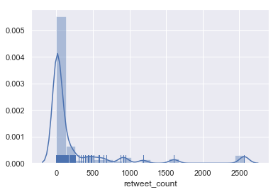

```python
sns.distplot(db3['retweet_count'].fillna(0), rug=True,bins=20)
```

#### What is the distribution of favortie counts?

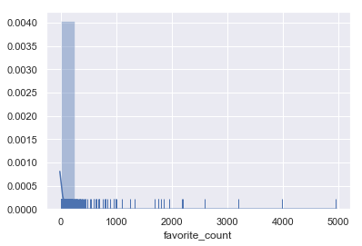

```python
sns.distplot(db3['favorite_count'].fillna(0), rug=True,bins=20)
```

#### Is there relationship between the number of retweets and number of likes?

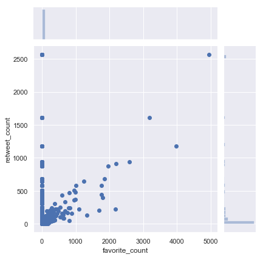

```python
sns.jointplot(x="favorite_count", y="retweet_count", data=db3.fillna(0))
```

It seems that people are more likely to retweet than "favorite" the tweets when reweets numbers are high

Zoom in the see the majority

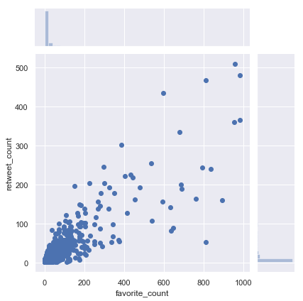

```python
sns.jointplot(x="favorite_count", y="retweet_count", data=db3[(db3['favorite_count'].fillna(0)<1000) & (db3['retweet_count'].fillna(0)<1000)]);
```

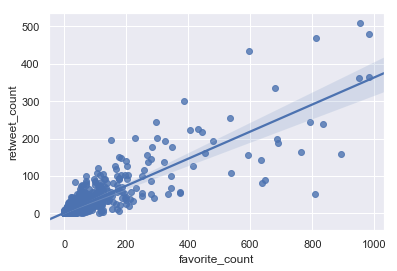

```python
sns.regplot(x="favorite_count", y="retweet_count", data=db3[(db3['favorite_count'].fillna(0)<1000) & (db3['retweet_count'].fillna(0)<1000)]);
```

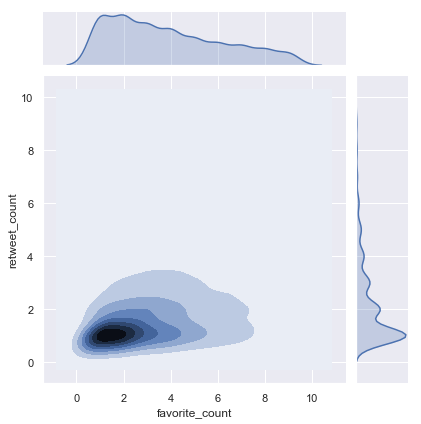

```python
sns.jointplot(x="favorite_count", y="retweet_count", data=db3[(db3['favorite_count'].fillna(0)<10) & (db3['retweet_count'].fillna(0)<10)], kind="kde");
```

## Wait! Let's do Novelty and Outlier Detection first!

One fact is that there are so many extreme values that affects the outcome of our viz, so I'd also like to perform an anomoly detection and try to normalize them.

```python
X_cols = ["favorite_count", "retweet_count"]
```

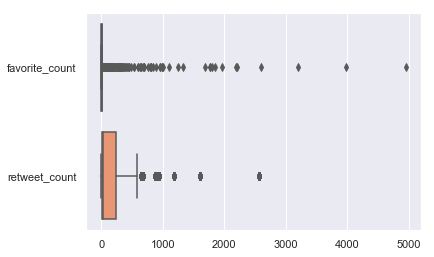

```python
sns.boxplot(data=db3[X_cols], orient="h", palette="Set2")
```

First, using the *IsolationForest* algorithm. It's a unsupervised machine learning techniques widely used in the industry.

I chose to find 5% of the records as outliers.

```python
from sklearn.ensemble import IsolationForest

ilf = IsolationForest(n_estimators=100,
                      n_jobs=-1,
                      verbose=2,
                      contamination=0.05
    )
```

```python
ilf=ilf.fit(db3[X_cols].fillna(0))
```

```
[Parallel(n_jobs=8)]: Done   3 out of   8 | elapsed:    1.4s remaining:    2.4s
[Parallel(n_jobs=8)]: Done   8 out of   8 | elapsed:    2.8s remaining:    0.0s
[Parallel(n_jobs=8)]: Done   8 out of   8 | elapsed:    2.8s finished

Using a non-tuple sequence for multidimensional indexing is deprecated; use `arr[tuple(seq)]` instead of `arr[seq]`. In the future this will be interpreted as an array index, `arr[np.array(seq)]`, which will result either in an error or a different result.
```

```python
db3['outlier_is']=ilf.predict(db3[X_cols].fillna(0))
```

```python
db3.outlier_is.value_counts()
```

```
 1    56226
-1     2990
Name: outlier_is, dtype: int64
```

Now it looks clearer...

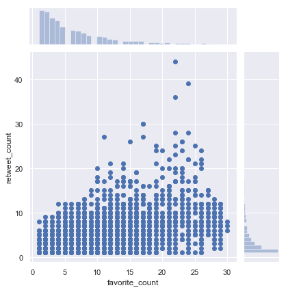

```python
sns.jointplot(x="favorite_count", y="retweet_count", data=db3[db3.outlier_is==1])
```

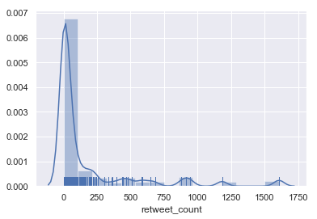

```python
sns.distplot(db3[db3.outlier_is==1]['retweet_count'].fillna(0), rug=True,bins=15)
```

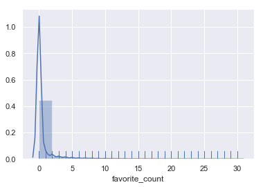

```python
sns.distplot(db3[db3.outlier_is==1]['favorite_count'].fillna(0), rug=True,bins=15)
```

Maybe try something else, maybe a density-based algorithm, DBSCAN

```python
from sklearn.cluster import DBSCAN
DBSCAN = DBSCAN(
      eps = 0.5,
  metric="euclidean",
  min_samples = 4,
  n_jobs = -1)
db3['outlier_dbs'] = DBSCAN.fit_predict(db3.fillna(0)[X_cols])
```

```python
len(db3[db3['outlier_dbs']==-1])
```

```
1031
```

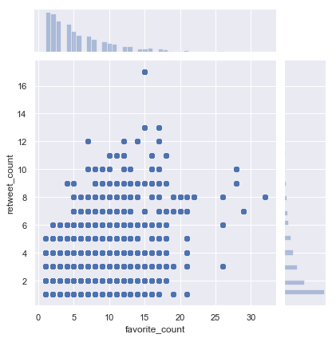

```python
sns.jointplot(x="favorite_count", y="retweet_count", data=db3[db3.outlier_dbs!=-1])
```

Interesting to see that in the majority, people are more incliend to favorite a tweet than to retweet.

Let's see the data about the users

Apparently, there must be some users tweeted more than once in this topic.

```python
users_tweet_count=db3.user_screen_name.value_counts()
```

```python
users_tweet_count.describe()
```

```
count    26097.000000
mean         2.269073
std         12.381945
min          1.000000
25%          1.000000
50%          1.000000
75%          1.000000
max       1271.000000
Name: user_screen_name, dtype: float64
```

So, there are 26097 unique users. One user posts 1271 tweets, but most of the users only post once.

Next, we keep a user dataset without duplicates

```python
user_set=db3.drop_duplicates(subset="user_screen_name")
```

```python
user_set=user_set.drop(columns="Unnamed: 0")
```

Again, there must be some outliers that would affect our visualization. Kick them out!

```python
from sklearn.ensemble import IsolationForest

ilf2 = IsolationForest(n_estimators=100,
                      n_jobs=-1,
                      verbose=2
    )
```

```python
ilf2=ilf2.fit(user_set.fillna(0).loc[:,["user_followers_count","user_friends_count","user_statuses_count","user_favourites_count"]])
```

```
[Parallel(n_jobs=8)]: Done   3 out of   8 | elapsed:    3.2s remaining:    5.3s
[Parallel(n_jobs=8)]: Done   8 out of   8 | elapsed:    4.6s remaining:    0.0s
[Parallel(n_jobs=8)]: Done   8 out of   8 | elapsed:    4.6s finished

Using a non-tuple sequence for multidimensional indexing is deprecated; use `arr[tuple(seq)]` instead of `arr[seq]`. In the future this will be interpreted as an array index, `arr[np.array(seq)]`, which will result either in an error or a different result.
```

```python
user_set['isoutlier_if']=ilf2.predict(user_set.fillna(0).loc[:,["user_followers_count","user_friends_count","user_statuses_count","user_favourites_count"]])
```

```python
user_set.isoutlier_if.value_counts()
```

```
 1    23487
-1     2610
Name: isoutlier_if, dtype: int64
```

```python
user_set[user_set['isoutlier_if']==-1]
```

|  | Unnamed: 0 | id_str | from_user | text | time | geo_coordinates | user_lang | in_reply_to_screen_name | from_user_id_str | in_reply_to_status_id_str | ... | possibly_sensitive | lang_trans | date | outlier_is | outlier_dbs | year | yearmon | month | trans_sour | isoutlier_if |
| --- | --- | --- | --- | --- | --- | --- | --- | --- | --- | --- | --- | --- | --- | --- | --- | --- | --- | --- | --- | --- | --- |
| 3 | 3 | 1099629537028071424 | IGD_News | RT @adaure: Drowned out by the chants of “go h... | 2019-02-24 11:18:06 | NaN | en | NaN | 3289440085 | NaN | ... | NaN | English | 2019-02-24 00:00:00 | 1 | 3 | 2019 | 2019-02 | 2 | Twitter for Android | -1 |
| 9 | 9 | 1099629921175924736 | cujowasagoodboy | RT @adaure: Drowned out by the chants of “go h... | 2019-02-24 11:19:38 | NaN | en | NaN | 60799419 | NaN | ... | NaN | English | 2019-02-24 00:00:00 | 1 | 3 | 2019 | 2019-02 | 2 | Twitter for Android | -1 |
| 17 | 17 | 1099748421790040070 | constantnatalie | RT @jordangreentcb: The coalition of neo-Confe... | 2019-02-24 19:10:30 | NaN | en | NaN | 279660360 | NaN | ... | NaN | English | 2019-02-24 00:00:00 | 1 | 5 | 2019 | 2019-02 | 2 | Twitter for Android | -1 |
| 69 | 69 | 1099439014740926464 | lola_patty | RT @adaure: Drowned out by the chants of “go h... | 2019-02-23 22:41:02 | NaN | en | NaN | 785213216854937600 | NaN | ... | NaN | English | 2019-02-23 00:00:00 | 1 | 3 | 2019 | 2019-02 | 2 | Twitter for Android | -1 |
| 70 | 70 | 1099443389483888640 | rhonda_harbison | RT @adaure: Drowned out by the chants of “go h... | 2019-02-23 22:58:25 | NaN | en | NaN | 864487498935787520 | NaN | ... | NaN | English | 2019-02-23 00:00:00 | 1 | 3 | 2019 | 2019-02 | 2 | Twitter Web App | -1 |
| 101 | 101 | 1099459489047236608 | shift_in2_turbo | RT @adaure: #LastManStanding a pro #SilentSam ... | 2019-02-24 00:02:23 | NaN | en | NaN | 110199502 | NaN | ... | NaN | English | 2019-02-24 00:00:00 | 1 | 18 | 2019 | 2019-02 | 2 | Twitter Web Client | -1 |
| 110 | 110 | 1099471237246529537 | wtf_imtooold | RT @BobKarpDR: A large group of students stage... | 2019-02-24 00:49:04 | NaN | en | NaN | 776959799871303681 | NaN | ... | NaN | English | 2019-02-24 00:00:00 | 1 | 16 | 2019 | 2019-02 | 2 | Twitter Web Client | -1 |
| 114 | 114 | 1099488511860920321 | GreenEyedLilo | RT @adaure: Drowned out by the chants of “go h... | 2019-02-24 01:57:43 | NaN | en | NaN | 119758837 | NaN | ... | NaN | English | 2019-02-24 00:00:00 | 1 | 3 | 2019 | 2019-02 | 2 | Twitter for iPhone | -1 |
| 119 | 119 | 1099522453708124160 | underoak | RT @jordangreentcb: The coalition of neo-Confe... | 2019-02-24 04:12:35 | NaN | en | NaN | 13575452 | NaN | ... | NaN | English | 2019-02-24 00:00:00 | 1 | 5 | 2019 | 2019-02 | 2 | Tweetbot for iΟS | -1 |
| 141 | 141 | 1099353757916295168 | WFMY | RT @adaure: Members of #HiersOfTheConfederacy ... | 2019-02-23 17:02:15 | NaN | en | NaN | 14361260 | NaN | ... | NaN | English | 2019-02-23 00:00:00 | 1 | 1 | 2019 | 2019-02 | 2 | TweetDeck | -1 |
| 152 | 152 | 1099355925725499393 | TheTattooedProf | RT @KevinLevin: Nothing like the sight of Afri... | 2019-02-23 17:10:52 | NaN | en | NaN | 2209778173 | NaN | ... | NaN | English | 2019-02-23 00:00:00 | 1 | 7 | 2019 | 2019-02 | 2 | Twitter for Android | -1 |
| 174 | 174 | 1099373415947952129 | bungdan | RT @azirulnick: During #SilentSam controversy ... | 2019-02-23 18:20:22 | NaN | en | NaN | 80669530 | NaN | ... | NaN | English | 2019-02-23 00:00:00 | 1 | 11 | 2019 | 2019-02 | 2 | Twitter Web Client | -1 |
| 179 | 179 | 1099033507869937670 | studentactivism | RT @newsobserver: Expect demonstrations and co... | 2019-02-22 19:49:41 | NaN | en | NaN | 20919626 | NaN | ... | NaN | English | 2019-02-22 00:00:00 | 1 | 16 | 2019 | 2019-02 | 2 | Twitter Web Client | -1 |
| 192 | 192 | 1099357051740774400 | SWS_EDU | RT @KevinLevin: Nothing like the sight of Afri... | 2019-02-23 17:15:20 | NaN | en | NaN | 1101298442 | NaN | ... | NaN | English | 2019-02-23 00:00:00 | 1 | 7 | 2019 | 2019-02 | 2 | Twitter for iPad | -1 |
| 208 | 208 | 1099032858029633536 | newsobserver | Expect demonstrations and counter-protests in ... | 2019-02-22 19:47:07 | NaN | en | NaN | 8942262 | NaN | ... | NaN | English | 2019-02-22 00:00:00 | 1 | 38 | 2019 | 2019-02 | 2 | SocialFlow | -1 |
| 232 | 232 | 1096457162992300034 | SpecNewsRDU | UNC graduate student, Maya Little, who was see... | 2019-02-15 17:12:13 | NaN | en | NaN | 17601174 | NaN | ... | NaN | English | 2019-02-15 00:00:00 | 1 | 42 | 2019 | 2019-02 | 2 | SocialNewsDesk | -1 |
| 235 | 235 | 1096487484236681216 | Cato_of_Utica | RT @sams_reckoning: @takeactionch @ChrisRember... | 2019-02-15 19:12:42 | NaN | en | NaN | 106520410 | NaN | ... | NaN | English | 2019-02-15 00:00:00 | 1 | 19 | 2019 | 2019-02 | 2 | Twitter Web Client | -1 |
| 255 | 255 | 1096457170831462400 | SpecNewsCLT | RT @SpecNewsRDU: UNC graduate student, Maya Li... | 2019-02-15 17:12:15 | NaN | en | NaN | 17601086 | NaN | ... | NaN | English | 2019-02-15 00:00:00 | 1 | 19 | 2019 | 2019-02 | 2 | SocialNewsDesk | -1 |
| 317 | 317 | 1096107303164624896 | SecularStudents | When Julian Carr spoke at the dedication cerem... | 2019-02-14 18:02:00 | NaN | en | NaN | 65305830 | NaN | ... | NaN | English | 2019-02-14 00:00:00 | 1 | 35 | 2019 | 2019-02 | 2 | TweetDeck | -1 |
| 327 | 327 | 1095543382854774784 | merrpppp | RT @JoelBrownABC11: A month after the last rem... | 2019-02-13 04:41:11 | NaN | en | NaN | 2986038667 | NaN | ... | NaN | English | 2019-02-13 00:00:00 | 1 | 46 | 2019 | 2019-02 | 2 | Twitter for iPhone | -1 |
| 339 | 339 | 1094263106581221376 | johnmanuelNC | RT @DennisDraughon: Blackface meets whitewash ... | 2019-02-09 15:53:49 | NaN | en | NaN | 125740053 | NaN | ... | NaN | English | 2019-02-09 00:00:00 | 1 | 1 | 2019 | 2019-02 | 2 | Twitter for iPhone | -1 |
| 345 | 345 | 1095146485774077952 | KellyRek | RT @RaleighReporter: Probably isn't surprising... | 2019-02-12 02:24:03 | NaN | en | NaN | 309558781 | NaN | ... | NaN | English | 2019-02-12 00:00:00 | 1 | 34 | 2019 | 2019-02 | 2 | Twitter for Android | -1 |
| 347 | 347 | 1095443060836745223 | UntoNuggan | RT @RavenRavinoff: The Costs of the Confederac... | 2019-02-12 22:02:32 | NaN | en | NaN | 3178522242 | NaN | ... | NaN | English | 2019-02-12 00:00:00 | 1 | 19 | 2019 | 2019-02 | 2 | Twitter for Android | -1 |
| 357 | 357 | 1095156691266605057 | wrongestwrong | RT @RaleighReporter: Probably isn't surprising... | 2019-02-12 03:04:36 | NaN | en | NaN | 91670958 | NaN | ... | NaN | English | 2019-02-12 00:00:00 | 1 | 34 | 2019 | 2019-02 | 2 | Twitter for iPhone | -1 |
| 359 | 359 | 1095512049826889728 | ABC11_WTVD | RT @JoelBrownABC11: A month after the last rem... | 2019-02-13 02:36:40 | NaN | en | NaN | 18342955 | NaN | ... | NaN | English | 2019-02-13 00:00:00 | 1 | 46 | 2019 | 2019-02 | 2 | TweetDeck | -1 |
| 368 | 368 | 1095148279350865921 | ZaRdOz420WPN | RT @RaleighReporter: Probably isn't surprising... | 2019-02-12 02:31:11 | NaN | en | NaN | 728180250 | NaN | ... | NaN | English | 2019-02-12 00:00:00 | 1 | 34 | 2019 | 2019-02 | 2 | Twitter for Android | -1 |
| 398 | 398 | 1094331964872626176 | WCCBCharlotte | RT @cjfranciscowccb: Bill to allow UNC to remo... | 2019-02-09 20:27:26 | NaN | en | NaN | 15080288 | NaN | ... | NaN | English | 2019-02-09 00:00:00 | 1 | 11 | 2019 | 2019-02 | 2 | Twitter Web Client | -1 |
| 401 | 401 | 1094248338973777920 | suemarietta | RT @kathyanderson22: Getting ready for #HKonJ ... | 2019-02-09 14:55:08 | NaN | en | NaN | 1342863121 | NaN | ... | NaN | English | 2019-02-09 00:00:00 | 1 | 1 | 2019 | 2019-02 | 2 | Twitter for iPad | -1 |
| 414 | 414 | 1094093094168002560 | JuiceGod23_ | RT @RaleighReporter: Probably isn't surprising... | 2019-02-09 04:38:15 | NaN | en | NaN | 116278535 | NaN | ... | NaN | English | 2019-02-09 00:00:00 | 1 | 34 | 2019 | 2019-02 | 2 | Twitter for iPhone | -1 |
| 461 | 461 | 1093900456877801473 | Turboturbulence | RT @RaleighReporter: Probably isn't surprising... | 2019-02-08 15:52:47 | NaN | en | NaN | 268025429 | NaN | ... | NaN | English | 2019-02-08 00:00:00 | 1 | 34 | 2019 | 2019-02 | 2 | Twitter for iPhone | -1 |
| ... | ... | ... | ... | ... | ... | ... | ... | ... | ... | ... | ... | ... | ... | ... | ... | ... | ... | ... | ... | ... | ... |
| 57977 | 58015 | 900147745574486017 | WatchAmandaTV | RT @Alvarez_TVNews: Crowd chanting "tear it do... | 2017-08-23 01:08:41 | NaN | en | NaN | 22540823 | NaN | ... | NaN | English | 2017-08-23 00:00:00 | 1 | 61 | 2017 | 2017-08 | 8 | Twitter Web Client | -1 |
| 57996 | 58034 | 900147547725078528 | JoeKoffee | RT @RedTRaccoon: Silent Sam protests are under... | 2017-08-23 01:07:53 | NaN | en | NaN | 601890937 | NaN | ... | NaN | English | 2017-08-23 00:00:00 | 1 | 90 | 2017 | 2017-08 | 8 | Twitter for Android | -1 |
| 57998 | 58036 | 900148268255936512 | iamforeverblue2 | RT @RedTRaccoon: Here are my previous statemen... | 2017-08-23 01:10:45 | NaN | en | NaN | 357232722 | NaN | ... | NaN | English | 2017-08-23 00:00:00 | 1 | 286 | 2017 | 2017-08 | 8 | Twitter for Android | -1 |
| 58001 | 58039 | 900148170528874497 | elyse4design | RT @RedTRaccoon: Here are my previous statemen... | 2017-08-23 01:10:22 | NaN | en | NaN | 253257813 | NaN | ... | NaN | English | 2017-08-23 00:00:00 | 1 | 286 | 2017 | 2017-08 | 8 | Twitter for iPad | -1 |
| 58007 | 58045 | 900145622690537473 | CathyJoeGPT | RT @RedTRaccoon: Here are my previous statemen... | 2017-08-23 01:00:15 | NaN | en | NaN | 738786290313920513 | NaN | ... | NaN | English | 2017-08-23 00:00:00 | 1 | 286 | 2017 | 2017-08 | 8 | Twitter Web Client | -1 |
| 58023 | 58061 | 900146750165364736 | 1Mamabear22 | RT @RedTRaccoon: Silent Sam protests are under... | 2017-08-23 01:04:43 | NaN | en | NaN | 825381228501094401 | NaN | ... | NaN | English | 2017-08-23 00:00:00 | 1 | 90 | 2017 | 2017-08 | 8 | Twitter for Windows | -1 |
| 58024 | 58062 | 900145202937044992 | miscastdice | RT @RedTRaccoon: Silent Sam protests are under... | 2017-08-23 00:58:34 | NaN | en | NaN | 48008292 | NaN | ... | NaN | English | 2017-08-23 00:00:00 | 1 | 90 | 2017 | 2017-08 | 8 | Twitter for iPhone | -1 |
| 58028 | 58066 | 900146465850478593 | JeanannBogar | RT @RedTRaccoon: Here are my previous statemen... | 2017-08-23 01:03:36 | NaN | en | NaN | 789282513038536704 | NaN | ... | NaN | English | 2017-08-23 00:00:00 | 1 | 286 | 2017 | 2017-08 | 8 | Twitter for Android | -1 |
| 58052 | 58090 | 900145839800147968 | FinishtheWall70 | RT @4ever2runval96: #SilentSam at UNC https://... | 2017-08-23 01:01:06 | NaN | en | NaN | 76184375 | NaN | ... | NaN | English | 2017-08-23 00:00:00 | 1 | 70 | 2017 | 2017-08 | 8 | Twitter for iPad | -1 |
| 58062 | 58100 | 900144710894977025 | GloriaLaw5 | RT @RedTRaccoon: Silent Sam protests are under... | 2017-08-23 00:56:37 | NaN | en | NaN | 825408035531190272 | NaN | ... | NaN | English | 2017-08-23 00:00:00 | 1 | 90 | 2017 | 2017-08 | 8 | Twitter Web Client | -1 |
| 58074 | 58112 | 900144275299676160 | zackmomma | RT @RedTRaccoon: Silent Sam protests are under... | 2017-08-23 00:54:53 | NaN | en | NaN | 171588704 | NaN | ... | NaN | English | 2017-08-23 00:00:00 | 1 | 90 | 2017 | 2017-08 | 8 | Twitter for iPad | -1 |
| 58109 | 58147 | 900144306777972736 | debperz1 | RT @RedTRaccoon: Silent Sam protests are under... | 2017-08-23 00:55:01 | NaN | en | NaN | 727293942 | NaN | ... | NaN | English | 2017-08-23 00:00:00 | 1 | 90 | 2017 | 2017-08 | 8 | Twitter Web Client | -1 |
| 58122 | 58160 | 900144162208702465 | ableraces | RT @RedTRaccoon: Here are my previous statemen... | 2017-08-23 00:54:26 | NaN | en | NaN | 55841409 | NaN | ... | NaN | English | 2017-08-23 00:00:00 | 1 | 286 | 2017 | 2017-08 | 8 | Twitter for iPhone | -1 |
| 58130 | 58168 | 900143723635494912 | Gigitrog | RT @RedTRaccoon: Silent Sam protests are under... | 2017-08-23 00:52:42 | NaN | en | NaN | 4035871276 | NaN | ... | NaN | English | 2017-08-23 00:00:00 | 1 | 90 | 2017 | 2017-08 | 8 | Twitter for Android | -1 |
| 58143 | 58181 | 900144490316476416 | aj_mirabelle | RT @RedTRaccoon: Silent Sam protests are under... | 2017-08-23 00:55:45 | NaN | en | NaN | 3734782041 | NaN | ... | NaN | English | 2017-08-23 00:00:00 | 1 | 90 | 2017 | 2017-08 | 8 | Twitter for Android | -1 |
| 58210 | 58248 | 900141017986473984 | Atwitisborn | RT @reecejhawaii: As a UNC alum, I'm glad to s... | 2017-08-23 00:41:57 | NaN | en | NaN | 28025132 | NaN | ... | NaN | English | 2017-08-23 00:00:00 | 1 | 1 | 2017 | 2017-08 | 8 | Twitter for Android | -1 |
| 58216 | 58254 | 900139947490934786 | susan_kay51 | RT @ajjanavelnews: Crowds chanting against rac... | 2017-08-23 00:37:41 | NaN | en | NaN | 706555539174645760 | NaN | ... | NaN | English | 2017-08-23 00:00:00 | 1 | 16 | 2017 | 2017-08 | 8 | Twitter Web App | -1 |
| 58424 | 58462 | 900131384664223744 | KendallMigues | #SilentSam https://t.co/ivhxbi92Sa | 2017-08-23 00:03:40 | NaN | en | NaN | 461747789 | NaN | ... | NaN | English | 2017-08-23 00:00:00 | 1 | 15 | 2017 | 2017-08 | 8 | Twitter Web Client | -1 |
| 58645 | 58683 | 900037460369035264 | rosethornne | RT @RedTRaccoon: @ChancellorFolt And this has ... | 2017-08-22 17:50:27 | NaN | en | NaN | 218787717 | NaN | ... | NaN | English | 2017-08-22 00:00:00 | 1 | 185 | 2017 | 2017-08 | 8 | Twitter for Android | -1 |
| 58669 | 58707 | 900036095311826946 | BonnieD87703006 | RT @RedTRaccoon: @ChancellorFolt And this has ... | 2017-08-22 17:45:01 | NaN | en | NaN | 761328485222658048 | NaN | ... | NaN | English | 2017-08-22 00:00:00 | 1 | 185 | 2017 | 2017-08 | 8 | Twitter for Android | -1 |
| 58742 | 58780 | 900015919057051648 | tod1776 | RT @JenDeplorable: Silent Sam statue is prepar... | 2017-08-22 16:24:51 | NaN | en | NaN | 719202585639460864 | NaN | ... | NaN | English | 2017-08-22 00:00:00 | 1 | 11 | 2017 | 2017-08 | 8 | Twitter Web Client | -1 |
| 58849 | 58887 | 899810154539085824 | RebeccaCokley | RT @SeeMiaRoll: This is why you need to come o... | 2017-08-22 02:47:13 | NaN | en | NaN | 2253654474 | NaN | ... | NaN | English | 2017-08-22 00:00:00 | 1 | 24 | 2017 | 2017-08 | 8 | Twitter for iPhone | -1 |
| 58924 | 58962 | 898742590836703232 | KeithBradsher | RT @DonnaLeinwand: The mayor of #ChapelHill, N... | 2017-08-19 04:05:06 | NaN | en | NaN | 161813561 | NaN | ... | NaN | English | 2017-08-19 00:00:00 | 1 | 24 | 2017 | 2017-08 | 8 | Twitter for iPhone | -1 |
| 58960 | 58998 | 898599339844526082 | Izandra | RT @Yamino: @UNC .@UNC has defended the racist... | 2017-08-18 18:35:52 | NaN | en | NaN | 34702148 | NaN | ... | NaN | English | 2017-08-18 00:00:00 | 1 | 1 | 2017 | 2017-08 | 8 | Twitter for iPhone | -1 |
| 59024 | 59062 | 897813587900628994 | Roxann_Minerals | Commemorating North Carolina’s anti-Confederat... | 2017-08-16 14:33:34 | NaN | en | NaN | 726089858607894529 | NaN | ... | NaN | English | 2017-08-16 00:00:00 | 1 | 11 | 2017 | 2017-08 | 8 | Twitter Web Client | -1 |
| 59030 | 59068 | 897633294086549504 | gastropoda | RT @chadastevens: I'll say it again: Remove #S... | 2017-08-16 02:37:09 | NaN | en | NaN | 15853490 | NaN | ... | NaN | English | 2017-08-16 00:00:00 | 1 | 1 | 2017 | 2017-08 | 8 | Twitter Web Client | -1 |
| 59059 | 59097 | 897407499309121536 | owenblacker | RT @damonseils: Similarly, #SilentSam was erec... | 2017-08-15 11:39:55 | NaN | en | NaN | 4491811 | NaN | ... | NaN | English | 2017-08-15 00:00:00 | 1 | 276 | 2017 | 2017-08 | 8 | Twitter for Android | -1 |
| 59120 | 59158 | 854710006440226816 | MarisolTexas | RT @CollegeFix: #BlackLivesMatter vandalism st... | 2017-04-19 15:55:19 | NaN | en | NaN | 749455671918297088 | NaN | ... | NaN | English | 2017-04-19 00:00:00 | 1 | 1 | 2017 | 2017-04 | 4 | Twitter for iPhone | -1 |
| 59154 | 59192 | 826455071936356352 | jasonjwilde | @Tahoe2014 They are. @SamZwick also misidentif... | 2017-01-31 15:40:18 | NaN | en | Tahoe2014 | 18964685 | 8.260839e+17 | ... | NaN | English | 2017-01-31 00:00:00 | 1 | 4 | 2017 | 2017-01 | 1 | TweetDeck | -1 |
| 59187 | 59225 | 780952354141024256 | Big_G_09 | @BradyTrett #SilentSam 👍 | 2016-09-28 03:08:45 | NaN | en | BradyTrett | 1060182799 | 7.805842e+17 | ... | NaN | English | 2016-09-28 00:00:00 | 1 | 4 | 2016 | 2016-09 | 9 | Twitter for BlackBerry | -1 |

2610 rows × 36 columns

```python
user_set['created_days']=datetime.datetime.now()-pd.to_datetime(user_set.user_created_at)
```

```python
user_set['created_days']=user_set['created_days'].astype('timedelta64[D]')
```

Six attributes in the user dataset could be viwed as countinous: **user_followers_count**, **user_friends_count**, **user_statuses_count**, **user_favourites_count**, **created days**, and **user_listed_count**

```python
user_set.loc[:,["user_followers_count","user_friends_count","user_statuses_count","user_favourites_count",'created_days','user_listed_count']]
```

|  | user_followers_count | user_friends_count | user_statuses_count | user_favourites_count | created_days | user_listed_count |
| --- | --- | --- | --- | --- | --- | --- |
| 0 | 38.0 | 294.0 | 305 | 1161.0 | 3352.0 | NaN |
| 1 | 12.0 | 98.0 | 818 | 1947.0 | 388.0 | NaN |
| 2 | 373.0 | 146.0 | 2665 | 2585.0 | 528.0 | 2.0 |
| 3 | 45665.0 | 1626.0 | 35727 | 22187.0 | 1327.0 | 691.0 |
| 4 | 2272.0 | 4343.0 | 35618 | 37056.0 | 3181.0 | 174.0 |
| 5 | 8.0 | NaN | 150 | 6.0 | 1264.0 | 6.0 |
| 6 | 2947.0 | 4640.0 | 33926 | 66291.0 | 2982.0 | 55.0 |
| 7 | 1732.0 | 1516.0 | 1737 | 12963.0 | 2084.0 | 12.0 |
| 8 | 85.0 | 46.0 | 82 | 31.0 | 1317.0 | NaN |
| 9 | 2306.0 | 2159.0 | 167938 | 366471.0 | 3514.0 | 193.0 |
| 10 | 195.0 | 1327.0 | 1249 | 10248.0 | 1820.0 | NaN |
| 11 | 392.0 | 1238.0 | 12450 | 33780.0 | 1746.0 | 7.0 |
| 12 | 206.0 | 331.0 | 564 | 3144.0 | 298.0 | 1.0 |
| 13 | 1419.0 | 852.0 | 2199 | 5843.0 | 189.0 | 15.0 |
| 14 | 539.0 | 73.0 | 3827 | 3668.0 | 3797.0 | 10.0 |
| 15 | 1675.0 | 2055.0 | 55658 | 76345.0 | 2236.0 | 104.0 |
| 16 | 160.0 | 552.0 | 5334 | 8724.0 | 2020.0 | 4.0 |
| 17 | 8499.0 | 9227.0 | 95389 | 10596.0 | 2893.0 | 328.0 |
| 18 | 499.0 | 389.0 | 15279 | 2486.0 | 3542.0 | 29.0 |
| 19 | 56.0 | 121.0 | 1480 | 1764.0 | 3146.0 | NaN |
| 20 | 1474.0 | 2626.0 | 1239 | 1158.0 | 830.0 | 21.0 |
| 21 | 473.0 | 419.0 | 5547 | 21557.0 | 2013.0 | 3.0 |
| 22 | 99.0 | 148.0 | 3863 | 976.0 | 2922.0 | 8.0 |
| 23 | 207.0 | 958.0 | 3991 | 91055.0 | 786.0 | NaN |
| 24 | 574.0 | 1049.0 | 138837 | 191582.0 | 2132.0 | 57.0 |
| 25 | 314.0 | 1243.0 | 4351 | 35187.0 | 1932.0 | 3.0 |
| 26 | 306.0 | 836.0 | 1587 | 4344.0 | 2754.0 | 27.0 |
| 27 | 240.0 | 104.0 | 2965 | 5976.0 | 557.0 | NaN |
| 28 | 854.0 | 4291.0 | 3225 | 4937.0 | 3479.0 | 6.0 |
| 29 | 8261.0 | 3416.0 | 81113 | 4604.0 | 3677.0 | 585.0 |
| ... | ... | ... | ... | ... | ... | ... |
| 59137 | 953.0 | 690.0 | 16360 | 9016.0 | 2806.0 | 28.0 |
| 59147 | 80.0 | 369.0 | 3669 | 2708.0 | 3197.0 | 20.0 |
| 59152 | 177.0 | 414.0 | 1812 | 8851.0 | 2821.0 | 3.0 |
| 59154 | 76101.0 | 2004.0 | 90816 | 8627.0 | 3709.0 | 2416.0 |
| 59161 | 26.0 | 70.0 | 25 | 1.0 | 1735.0 | NaN |
| 59163 | 175.0 | 448.0 | 752 | 1922.0 | 883.0 | NaN |
| 59165 | 4469.0 | 2575.0 | 29198 | 19211.0 | 2043.0 | 139.0 |
| 59172 | 25.0 | 104.0 | 1085 | 1332.0 | 3578.0 | NaN |
| 59177 | 404.0 | 870.0 | 15863 | 1505.0 | 3591.0 | 62.0 |
| 59178 | 154.0 | 313.0 | 145 | 57.0 | 1456.0 | 2.0 |
| 59179 | 1366.0 | 698.0 | 84177 | 3887.0 | 2786.0 | 7.0 |
| 59182 | 31.0 | 199.0 | 366 | 122.0 | 1398.0 | 1.0 |
| 59183 | 656.0 | 1783.0 | 2694 | 4087.0 | 1271.0 | 28.0 |
| 59184 | 3034.0 | 2067.0 | 12194 | 16703.0 | 3296.0 | 52.0 |
| 59185 | 665.0 | 402.0 | 791 | 210.0 | 3458.0 | 44.0 |
| 59186 | 4827.0 | 3892.0 | 7870 | 1711.0 | 3891.0 | 221.0 |
| 59187 | 11299.0 | 12145.0 | 148392 | 63506.0 | 2258.0 | 341.0 |
| 59190 | 1652.0 | 883.0 | 34328 | 18945.0 | 2798.0 | 3.0 |
| 59192 | 22.0 | 48.0 | 183 | 34.0 | 1162.0 | NaN |
| 59193 | 172.0 | 154.0 | 640 | 28.0 | 2233.0 | 4.0 |
| 59196 | 1589.0 | 262.0 | 3845 | 3199.0 | 2401.0 | 39.0 |
| 59198 | 17077.0 | 2818.0 | 19198 | 5767.0 | 3689.0 | 463.0 |
| 59199 | 665.0 | 326.0 | 1278 | 715.0 | 1384.0 | 12.0 |
| 59200 | 3802.0 | 4944.0 | 34274 | 92127.0 | 1958.0 | 50.0 |
| 59202 | 218.0 | 793.0 | 24181 | 31729.0 | 2781.0 | 5.0 |
| 59203 | 206.0 | 785.0 | 5927 | 3316.0 | 1830.0 | 3.0 |
| 59204 | 34.0 | 103.0 | 132 | 158.0 | 829.0 | NaN |
| 59205 | 30.0 | 57.0 | 320 | 46.0 | 1102.0 | 1.0 |
| 59213 | 8.0 | 11.0 | 115 | NaN | 2554.0 | 3.0 |
| 59214 | 915.0 | 95.0 | 2387 | 34080.0 | 2810.0 | 1.0 |

26097 rows × 6 columns

**Correlation between the attributes**

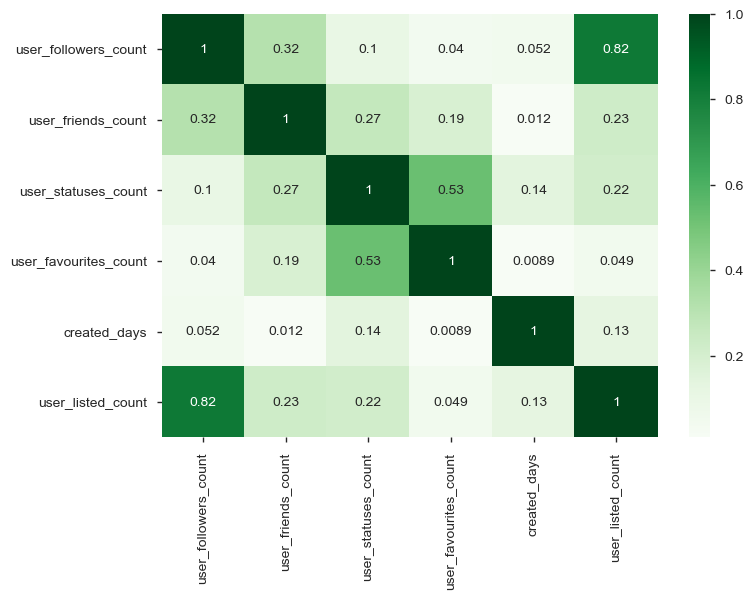

```python
sns.heatmap(user_set.loc[:,["user_followers_count","user_friends_count","user_statuses_count","user_favourites_count",'created_days','user_listed_count']].corr(),annot=True,cmap="Greens")
```

#### Let's have a look at the linear fitting matrix

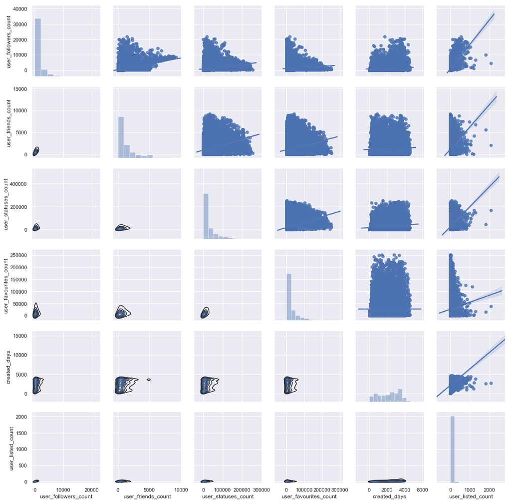

```python
g = sns.PairGrid(data=user_set[user_set['isoutlier_if']!=-1].loc[:,["user_followers_count","user_friends_count","user_statuses_count","user_favourites_count",'created_days','user_listed_count']].fillna(0))
g.map_diag(sns.distplot,kde=False, bins=10)
g.map_upper(sns.regplot)
g.map_lower(sns.kdeplot)
```

```python
user_set.columns
```

```
Index(['id_str', 'from_user', 'text', 'time', 'geo_coordinates', 'user_lang',
       'in_reply_to_screen_name', 'from_user_id_str',
       'in_reply_to_status_id_str', 'source', 'user_followers_count',
       'user_friends_count', 'user_location', 'entities_str', 'place',
       'retweet_count', 'favorite_count', 'user_description',
       'user_created_at', 'user_geo_enabled', 'user_listed_count',
       'user_verified', 'user_statuses_count', 'user_screen_name',
       'user_favourites_count', 'possibly_sensitive', 'lang_trans', 'date',
       'outlier_is', 'outlier_dbs', 'isoutlier_if', 'created_days'],
      dtype='object')
```

## Categorical Atrributes Exploration

#### Count the number of different language users

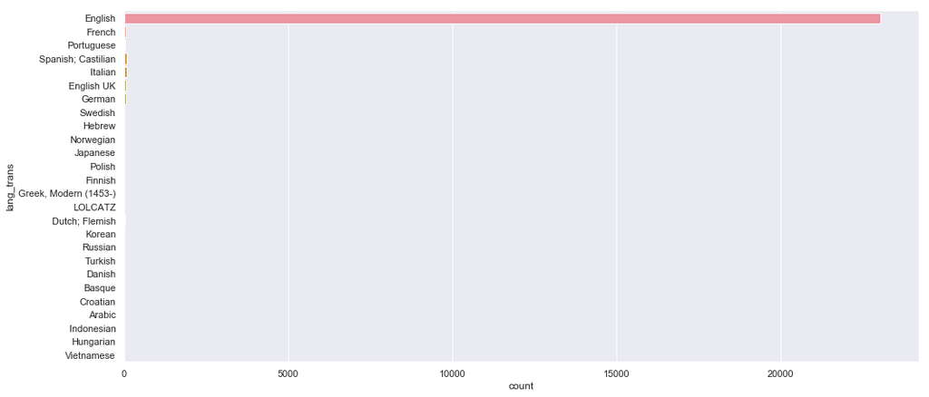

```python
sns.catplot(y="lang_trans", data=user_set[user_set['isoutlier_if']!=-1], kind="count",height=6.27, aspect=16/6.7)
```

#### Number of tweets of the users and their language

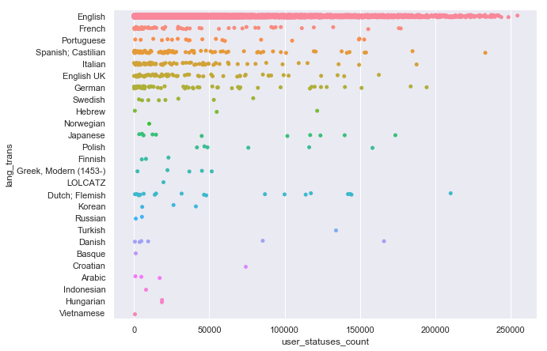

```python
sns.catplot(y="lang_trans", x="user_statuses_count", data=user_set[user_set['isoutlier_if']!=-1], height=6.27, aspect=9.7/6.27)
```

#### Number of friends of the users and their language

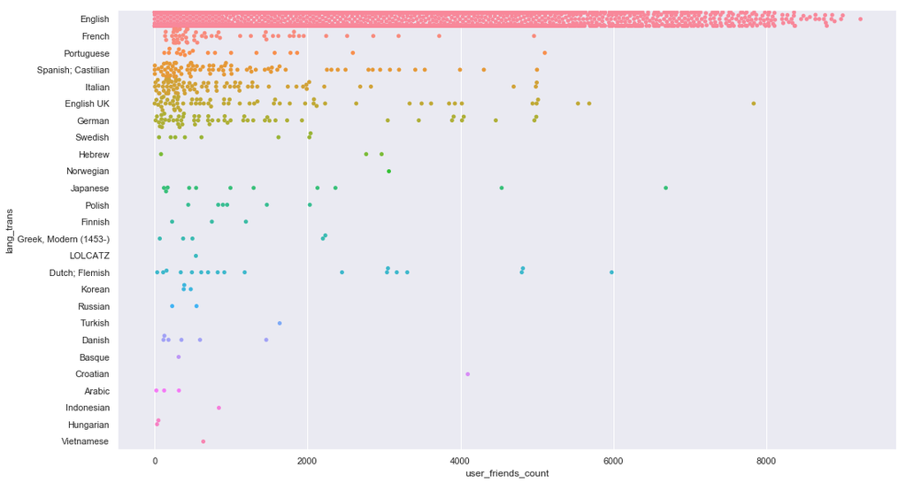

```python
sns.catplot(y="lang_trans", x="user_friends_count",kind="swarm", data=user_set[user_set['isoutlier_if']!=-1], height=8.27, aspect=11.7/6.27)
```

#### Number of favorites of the users and their language

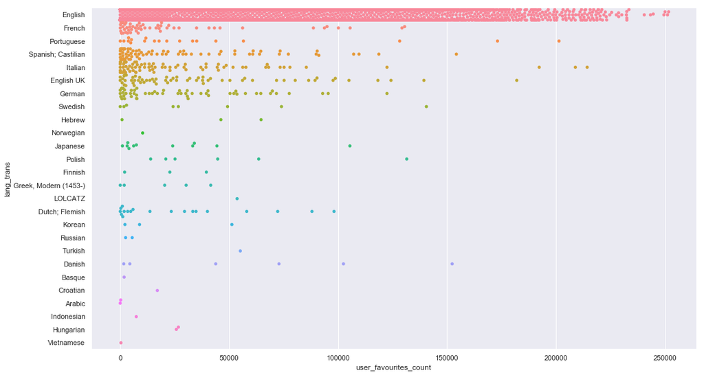

```python
sns.catplot(y="lang_trans", x="user_favourites_count",kind="swarm", data=user_set[user_set['isoutlier_if']!=-1], height=8.27, aspect=11.7/6.27)
```

#### Generate a new attribute about language, just indicating the user using English or nor

```python
user_set["eng_or_not"]=user_set.lang_trans.map(lambda x: "English" if x=="English" else "Non-English")
```

```python
new_user_set=user_set.set_index("user_screen_name")
```

##### convert wide table to long table

```python
new_long=new_user_set.stack().reset_index()[new_user_set.stack().reset_index().level_1.isin(["retweet_count","favorite_count"])]
```

```python
new_long=pd.merge(new_long, user_set, on="user_screen_name").iloc[:,[0,1,2,-1]]
new_long.columns=['user_screen_name',"type","value","eng_or_not"]
```

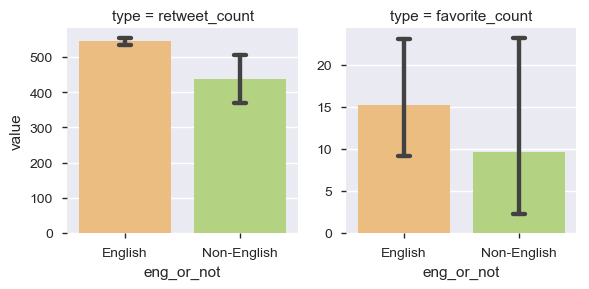

```python
long_fct=sns.FacetGrid(data=new_long, col="type",hue="eng_or_not",sharey=False, palette=ran_pat())
long_fct.map(sns.barplot, "eng_or_not", "value",order=['English','Non-English'], capsize=0.1 )
```

```python
user_atts=new_user_set.stack().reset_index()[new_user_set.stack().reset_index().level_1.isin(["user_followers_count","user_friends_count","user_statuses_count","user_favourites_count",'created_days','user_listed_count','tweets_num'])]
```

```python
user_atts=pd.merge(user_atts, user_set, on="user_screen_name").iloc[:,[0,1,2,-1]]
user_atts.columns=['user_screen_name',"type","value","eng_or_not"]
```

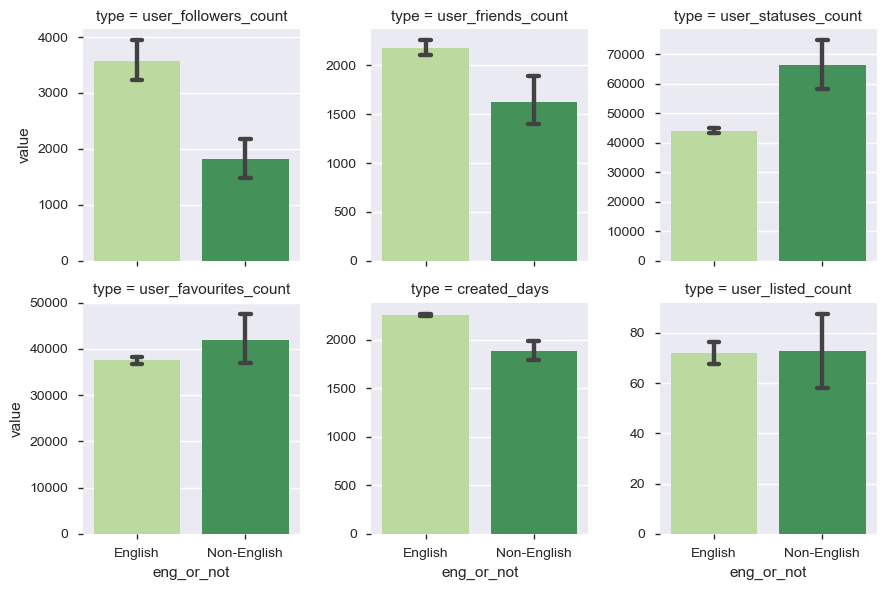

```python
long_fct2=sns.FacetGrid(data=user_atts, col="type",col_wrap=3, hue="eng_or_not",sharey=False, palette=ran_pat())
long_fct2.map(sns.barplot, "eng_or_not", "value",order=['English','Non-English'], capsize=0.1 )
```

#### Taking Geo_Enable into consideration. Now we have 4 dimensions.

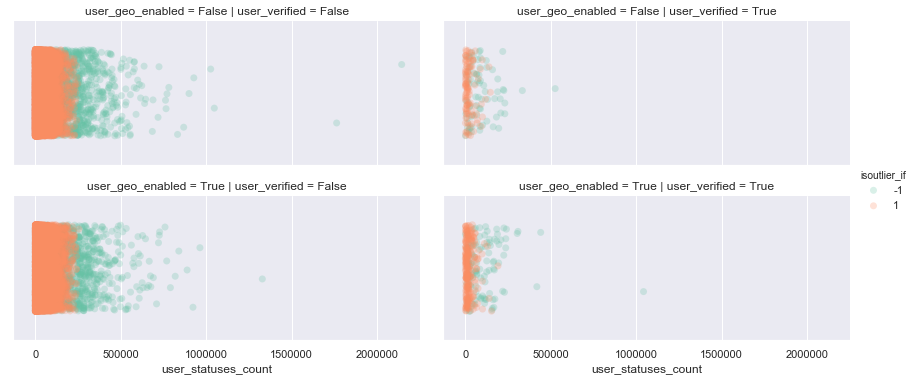

```python
m=sns.FacetGrid(user_set.fillna(False), col="user_verified", row="user_geo_enabled",height=2.7, aspect=6/2.7, hue='isoutlier_if', legend_out=True,palette=sns.color_palette("Set2"))
m.map(sns.stripplot, "user_statuses_count",jitter=0.3, dodge=True,alpha=.25,size=7).add_legend()
```

```python
user_set.user_geo_enabled.value_counts()
```

```
True    10984
Name: user_geo_enabled, dtype: int64
```

#### Taking User_Verified into consideration.

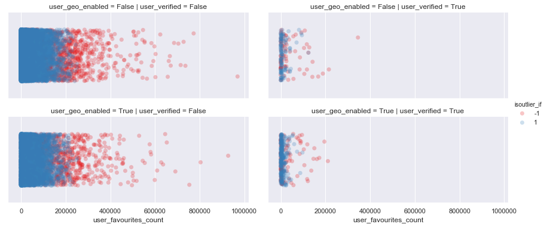

```python
m1=sns.FacetGrid(user_set.fillna(False), col="user_verified", row="user_geo_enabled",height=2.7, aspect=6/2.7, hue='isoutlier_if', legend_out=True,palette=sns.color_palette("Set1"))
m1.map(sns.stripplot, "user_favourites_count",jitter=0.3, dodge=True,alpha=.25,size=7).add_legend()
```

#### Generating a new attribute: number of tweets about Silent Sam for each user

```python
db4=db3.user_screen_name.value_counts()
```

```python
db4=db4.reset_index()
```

```python
db4.columns=['user_screen_name','tweets_num']
```

```python
db4=pd.merge(db4, user_set, on="user_screen_name")
```

#### The number of tweets of Silent Sam has something to do with...?

```python
db4["eng_or_not"]=db4.lang_trans.map(lambda x: "English" if x=="English" else "Non-English")
```

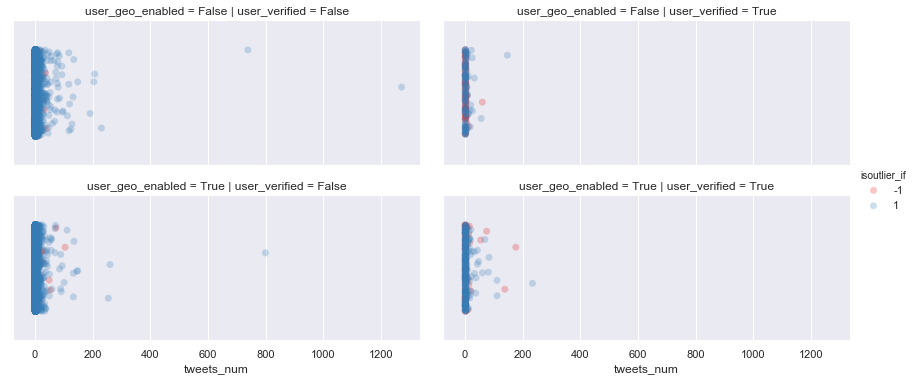

```python
m1=sns.FacetGrid(db4.fillna(False), col="user_verified", row="user_geo_enabled",height=2.7, aspect=6/2.7, hue='isoutlier_if', legend_out=True,palette=sns.color_palette("Set1"))
m1.map(sns.stripplot, "tweets_num",jitter=0.3, dodge=True,alpha=.25,size=7).add_legend()
```

#### Number of SlientSam tweets bears relationship with ...?

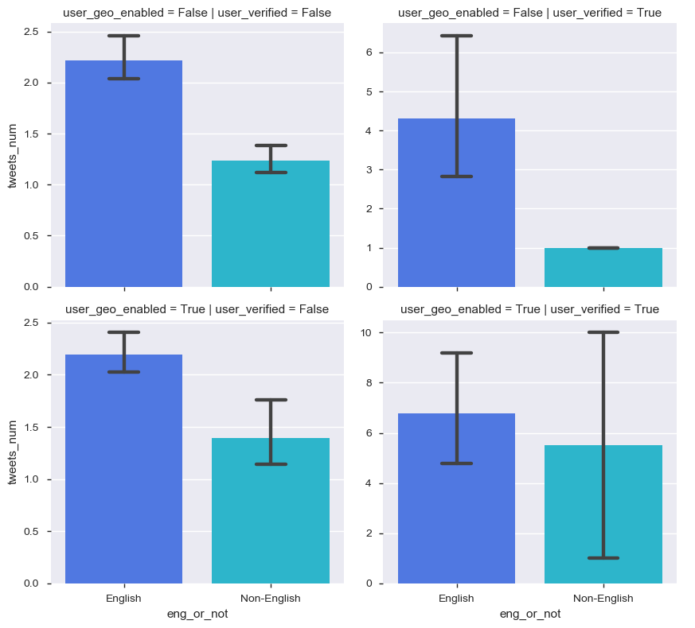

```python
m1=sns.FacetGrid(db4.fillna(False), col="user_verified", row="user_geo_enabled",height=4, aspect=4/3.7, sharey=False)
m1.map(sns.barplot, 'eng_or_not',"tweets_num", palette=sns.color_palette("rainbow"), estimator=np.mean,capsize=.2).add_legend()
```

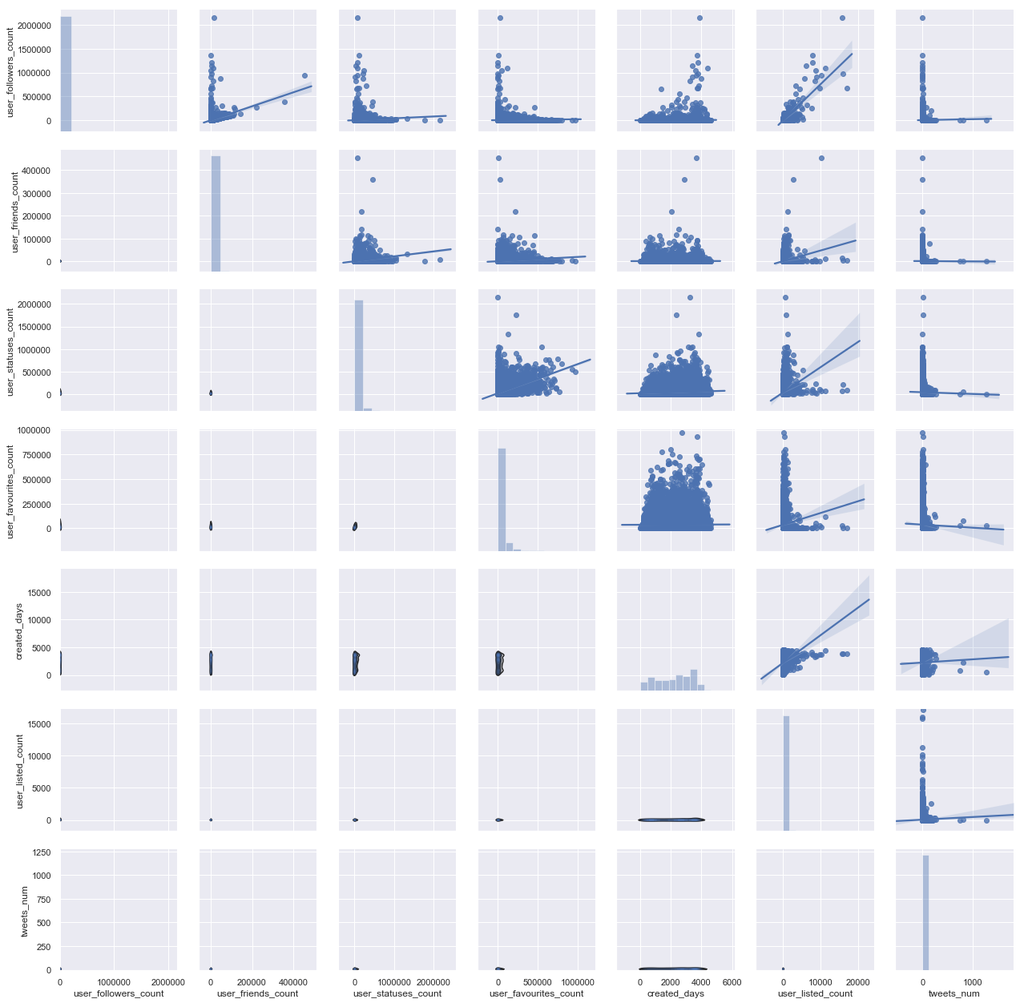

```python
gg = sns.PairGrid(data=db4.loc[:,["user_followers_count","user_friends_count","user_statuses_count","user_favourites_count",'created_days','user_listed_count','tweets_num']].fillna(0))
gg.map_diag(sns.distplot,kde=False, bins=10)
gg.map_upper(sns.regplot)
gg.map_lower(sns.kdeplot)
```

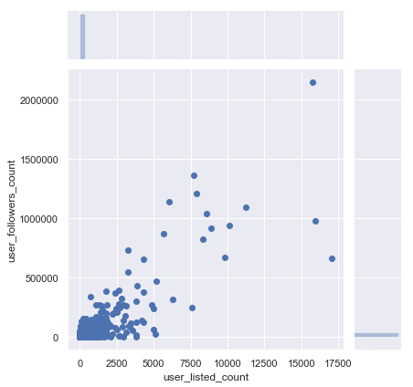

```python
sns.jointplot(data=db4, x='user_listed_count', y="user_followers_count")
```

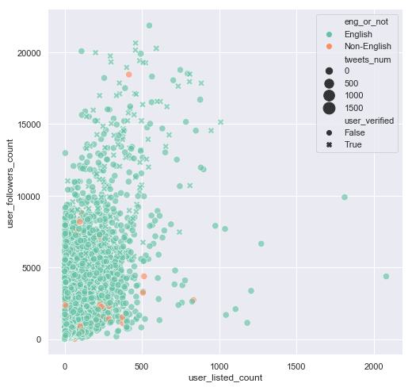

```python
f, ax = plt.subplots(figsize=(8, 8))
sns.despine(f, left=True, bottom=True)
sns.scatterplot(data=db4[db4.isoutlier_if!=-1].fillna(False), x='user_listed_count', y="user_followers_count",style="user_verified", hue="eng_or_not",size="tweets_num",
                alpha=0.65,sizes=(70, 220),x_jitter=0.5, y_jitter=0.5, palette="Set2", ax=ax)
#sns.lineplot(data=db4[db4.isoutlier_if!=-1].fillna(False), x='user_listed_count', y='user_followers_count')
```

### Introducing the Time Factor

```python
db3.date=pd.to_datetime(db3.date)
```

```python
db3['year']=db3.date.dt.year
```

```python
db3['month']=db3.date.dt.month
```

```python
db3['yearmon']=db3.date.dt.to_period('M')
```

```python
t=db3.groupby(["year","month"]).count()
```

```python
tt=t.reset_index().iloc[:,0:3]
```

```python
tt.columns=['year', 'month', 'tweet_count']
tt=tt.pivot('year','month','tweet_count')
```

```python
tt=tt.fillna(0)
tt=tt.astype(int)
```

#### Number of Tweets about SilentSam in different months

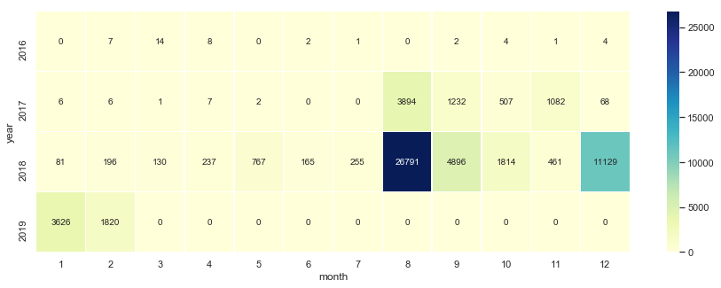

```python
f, ax = plt.subplots(figsize=(15, 5))
sns.heatmap(tt, annot=True, linewidths=.5,fmt='g',cmap="YlGnBu", ax=ax)
```

```python
dd=db3.groupby(['year','month']).user_screen_name.nunique().reset_index()
```

```python
dd=dd.pivot('year','month','user_screen_name')
dd=dd.fillna(0)
dd=dd.astype(int)
```

#### Number of unique users in different months

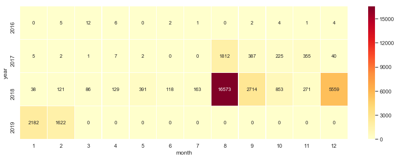

```python
f, ax = plt.subplots(figsize=(15, 5))
sns.heatmap(dd, annot=True, linewidths=.5,fmt='g',cmap="YlOrRd", ax=ax)
```

```python
unptt=tt.unstack()
```

```python
db3.groupby("yearmon").id_str.count().index
```

```
PeriodIndex(['2016-02', '2016-03', '2016-04', '2016-06', '2016-07', '2016-09',
             '2016-10', '2016-11', '2016-12', '2017-01', '2017-02', '2017-03',
             '2017-04', '2017-05', '2017-08', '2017-09', '2017-10', '2017-11',
             '2017-12', '2018-01', '2018-02', '2018-03', '2018-04', '2018-05',
             '2018-06', '2018-07', '2018-08', '2018-09', '2018-10', '2018-11',
             '2018-12', '2019-01', '2019-02'],
            dtype='period[M]', name='yearmon', freq='M')
```

#### Line plot

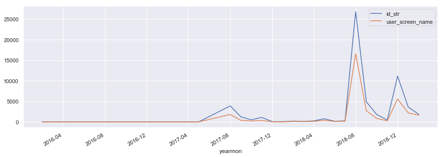

```python
db3.groupby("yearmon").id_str.count().plot(figsize=(15,5),x_compat=True,legend=True,sharey=False)
db3.groupby("yearmon").user_screen_name.nunique().plot(figsize=(15,5),x_compat=True,legend=True,sharey=False)
```